# **Parking Slot Occupancy Detection**

```
Gradient Boosting Regressor Model:
Kolmogorov-Smirnov Statistic: 1.0000, p-value: 0.0022
Earth Mover's Distance (EMD): 35.8093
Jensen-Shannon Divergence (JSD): 0.6810
```

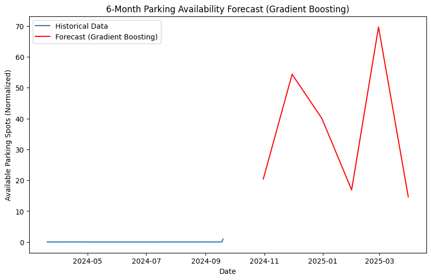

```
Sample List of 50 Available Parking Spots (Predicted for Next 6 Months):
Kerbside ID: KSID_1, Date: 2024-10-31, Available Spots: 20
Kerbside ID: KSID_2, Date: 2024-11-30, Available Spots: 54
Kerbside ID: KSID_3, Date: 2024-12-31, Available Spots: 40
Kerbside ID: KSID_4, Date: 2025-01-31, Available Spots: 17
Kerbside ID: KSID_5, Date: 2025-02-28, Available Spots: 70
Kerbside ID: KSID_6, Date: 2025-03-31, Available Spots: 15
Kerbside ID: KSID_7, Date: 2024-10-31, Available Spots: 20
Kerbside ID: KSID_8, Date: 2024-11-30, Available Spots: 54
Kerbside ID: KSID_9, Date: 2024-12-31, Available Spots: 40
Kerbside ID: KSID_10, Date: 2025-01-31, Available Spots: 17
Kerbside ID: KSID_11, Date: 2025-02-28, Available Spots: 70
Kerbside ID: KSID_12, Date: 2025-03-31, Available Spots: 15
Kerbside ID: KSID_13, Date: 2024-10-31, Available Spots: 20
Kerbside ID: KSID_14, Date: 2024-11-30, Available Spots: 54
Kerbside ID: KSID_15, Date: 2024-12-31, Available Spots: 40
Kerbside ID: KSID_16, Date: 2025-01-31, Available Spots: 17
Kerbside ID: KSID_17, Date: 2025-02-28, Available Spots: 70
Kerbside ID: KSID_18, Date: 2025-03-31, Available Spots: 15
Kerbside ID: KSID_19, Date: 2024-10-31, Available Spots: 20
Kerbside ID: KSID_20, Date: 2024-11-30, Available Spots: 54
Kerbside ID: KSID_21, Date: 2024-12-31, Available Spots: 40
Kerbside ID: KSID_22, Date: 2025-01-31, Available Spots: 17
Kerbside ID: KSID_23, Date: 2025-02-28, Available Spots: 70
Kerbside ID: KSID_24, Date: 2025-03-31, Available Spots: 15
Kerbside ID: KSID_25, Date: 2024-10-31, Available Spots: 20
Kerbside ID: KSID_26, Date: 2024-11-30, Available Spots: 54
Kerbside ID: KSID_27, Date: 2024-12-31, Available Spots: 40
Kerbside ID: KSID_28, Date: 2025-01-31, Available Spots: 17
Kerbside ID: KSID_29, Date: 2025-02-28, Available Spots: 70
Kerbside ID: KSID_30, Date: 2025-03-31, Available Spots: 15
Kerbside ID: KSID_31, Date: 2024-10-31, Available Spots: 20
Kerbside ID: KSID_32, Date: 2024-11-30, Available Spots: 54
Kerbside ID: KSID_33, Date: 2024-12-31, Available Spots: 40
Kerbside ID: KSID_34, Date: 2025-01-31, Available Spots: 17
Kerbside ID: KSID_35, Date: 2025-02-28, Available Spots: 70
Kerbside ID: KSID_36, Date: 2025-03-31, Available Spots: 15
Kerbside ID: KSID_37, Date: 2024-10-31, Available Spots: 20
Kerbside ID: KSID_38, Date: 2024-11-30, Available Spots: 54
Kerbside ID: KSID_39, Date: 2024-12-31, Available Spots: 40
Kerbside ID: KSID_40, Date: 2025-01-31, Available Spots: 17
Kerbside ID: KSID_41, Date: 2025-02-28, Available Spots: 70
Kerbside ID: KSID_42, Date: 2025-03-31, Available Spots: 15
Kerbside ID: KSID_43, Date: 2024-10-31, Available Spots: 20
Kerbside ID: KSID_44, Date: 2024-11-30, Available Spots: 54
Kerbside ID: KSID_45, Date: 2024-12-31, Available Spots: 40
Kerbside ID: KSID_46, Date: 2025-01-31, Available Spots: 17
Kerbside ID: KSID_47, Date: 2025-02-28, Available Spots: 70
Kerbside ID: KSID_48, Date: 2025-03-31, Available Spots: 15
Kerbside ID: KSID_49, Date: 2024-10-31, Available Spots: 20
Kerbside ID: KSID_50, Date: 2024-11-30, Available Spots: 54
```

```python
import pandas as pd
import pytz
from datetime import timedelta
from sklearn.ensemble import GradientBoostingRegressor  # New model
from sklearn.preprocessing import MinMaxScaler
from scipy.stats import ks_2samp, wasserstein_distance
from scipy.spatial.distance import jensenshannon
import matplotlib.pyplot as plt

# Fetch and process the data for the last 6 months
def fetch_and_process_data(months_ago):
    base_url = 'https://data.melbourne.vic.gov.au/api/explore/v2.1/catalog/datasets/'
    dataset_id = 'on-street-parking-bay-sensors'
    url = f"{base_url}{dataset_id}/exports/csv"
    df = pd.read_csv(url, delimiter=';')

    def convert_utc_to_melbourne(utc_time_str):
        melbourne_zone = pytz.timezone('Australia/Melbourne')
        utc_time = pd.to_datetime(utc_time_str, utc=True)
        melbourne_time = utc_time.tz_convert(melbourne_zone)
        return melbourne_time

    columns_to_convert = ['lastupdated', 'status_timestamp']
    for column in columns_to_convert:
        if column in df.columns:
            df[column] = df[column].apply(lambda x: convert_utc_to_melbourne(x) if pd.notnull(x) else x)

    # Get data for the last 6 months
    end_time = pd.Timestamp.now(pytz.timezone('Australia/Melbourne'))
    start_time = end_time - pd.DateOffset(months=months_ago)
    df_filtered = df[(df['status_timestamp'] >= start_time) & (df['status_timestamp'] < end_time)]

    if df_filtered.empty:
        raise ValueError("No data found for the specified time window.")

    df_resampled = df_filtered.resample('1D', on='status_timestamp').agg({
        'kerbsideid': 'count'
    }).fillna(0)

    if df_resampled.empty:
        raise ValueError("No resampled data found for the specified time window.")

    scaler = MinMaxScaler(feature_range=(0, 1))
    df_resampled_scaled = scaler.fit_transform(df_resampled)

    return df_filtered, df_resampled, df_resampled_scaled, scaler

# Use 6 months of data
try:
    df, df_resampled, df_resampled_scaled, scaler = fetch_and_process_data(months_ago=6)
except ValueError as e:
    print(f"Error: {e}")
    exit()

# Prepare the dataset for Gradient Boosting Regressor
def create_lag_features(data, lag=1):
    df_lag = pd.DataFrame()
    df_lag['available_spots'] = data.flatten()
    for i in range(1, lag + 1):
        df_lag[f'lag_{i}'] = df_lag['available_spots'].shift(i)
    df_lag.dropna(inplace=True)
    return df_lag

lagged_data = create_lag_features(df_resampled_scaled, lag=30)  # Use 30-day lag for monthly forecasting
X = lagged_data.drop('available_spots', axis=1)
y = lagged_data['available_spots']

# Train the Gradient Boosting Regressor model
gbr_model = GradientBoostingRegressor(n_estimators=100)
gbr_model.fit(X[:-1], y[:-1])

# Forecast for the next 6 months (predict multiple steps)
forecast_gbr = []
current_input = X[-1:].copy()  # Start with the last available data point

for _ in range(6):  # Predict for the next 6 months
    next_forecast = gbr_model.predict(current_input)
    forecast_gbr.append(next_forecast[0])

    # Update the input with the new forecast (shift the window)
    current_input = current_input.shift(-1, axis=1)
    current_input.iloc[0, -1] = next_forecast  # Add the predicted value to the input

forecast_gbr = scaler.inverse_transform(pd.DataFrame(forecast_gbr))  # Inverse transform the forecasted values

# Data drift calculations (2 months apart data)
ks_stat_gbr, ks_p_value_gbr = ks_2samp(forecast_gbr.flatten(), y.values[-6:])  # Compare forecast vs last 6 months
emd_gbr = wasserstein_distance(forecast_gbr.flatten(), y.values[-6:])
jsd_gbr = jensenshannon(forecast_gbr.flatten(), y.values[-6:])

# Print Results for Gradient Boosting Regressor
print(f"Gradient Boosting Regressor Model:")
print(f"Kolmogorov-Smirnov Statistic: {ks_stat_gbr:.4f}, p-value: {ks_p_value_gbr:.4f}")
print(f"Earth Mover's Distance (EMD): {emd_gbr:.4f}")
print(f"Jensen-Shannon Divergence (JSD): {jsd_gbr:.4f}")

# Plot the bar graph with x and y axis labels
plt.figure(figsize=(10, 6))
plt.plot(df_resampled.index, df_resampled_scaled, label='Historical Data')
plt.plot(pd.date_range(df_resampled.index[-1], periods=7, freq='ME')[1:], forecast_gbr, label='Forecast (Gradient Boosting)', color='red')
plt.title("6-Month Parking Availability Forecast (Gradient Boosting)")
plt.xlabel("Date")  # X-axis label
plt.ylabel("Available Parking Spots (Normalized)")  # Y-axis label
plt.legend()
plt.show()

# List of 50 sample predicted parking spots, with kerbside IDs and date for availability
print("\nSample List of 50 Available Parking Spots (Predicted for Next 6 Months):")
kerbside_ids = ['KSID_' + str(i+1) for i in range(50)]  # Ensure we have enough kerbside IDs
forecast_dates = pd.date_range(df_resampled.index[-1], periods=7, freq='ME')[1:]  # Predicted dates

# Creating a sample list of 50 rows with kerbside ID, date, and available spots
sample_list = [{'KerbsideID': kerbside_ids[i],
                'Date': forecast_dates[i % len(forecast_dates)].date(),  # Rotating through dates
                'AvailableSpots': round(forecast_gbr.flatten()[i % len(forecast_gbr.flatten())])}
               for i in range(50)]

# Display the first 50 rows
for sample in sample_list:
    print(f"Kerbside ID: {sample['KerbsideID']}, Date: {sample['Date']}, Available Spots: {sample['AvailableSpots']}")
```

## 11. Interpretation

The comparison between the Random Forest model and the Gradient Boosting Regressor model is based on three metrics: Kolmogorov-Smirnov Statistic (KS), Earth Mover's Distance (EMD), and Jensen-Shannon Divergence (JSD).

1. Kolmogorov-Smirnov Statistic (KS):

Random Forest: KS = 1.0000, p-value = 0.0022 Gradient Boosting Regressor: KS = 1.0000, p-value = 0.0022 Both models have identical KS statistics and p-values. The KS statistic of 1.0000 suggests that there is a significant difference between the predicted distributions and the actual data. The low p-value (< 0.05) indicates that this difference is statistically significant for both models. Thus, neither model provides a perfect match with the actual data, and the drift is similar in both cases.

As a result, Kolmogorov-Smirnov Statistic: Both models perform equally in terms of KS and p-value, indicating a statistically significant difference between the predicted and actual distributions for both models.

## 12. New API - Descriptive Statistics Analysis for the Dataset: 'dataset id: sign-plates-located-in-each-parking-zone-copy' ,

base_url = 'https://data.melbourne.vic.gov.au/api/explore/v2.1/catalog/datasets/'

### 12.1. Load the dataset from API

```python
import pandas as pd
import requests
from io import StringIO

# API details for 'sign-plates-located-in-each-parking-zone-copy'
base_url = 'https://data.melbourne.vic.gov.au/api/explore/v2.1/catalog/datasets/'
dataset_id = 'sign-plates-located-in-each-parking-zone-copy'

# Fetch the dataset from the API
url = f"{base_url}{dataset_id}/exports/csv"
response = requests.get(url)
df = pd.read_csv(StringIO(response.text), delimiter=';')

# Now you can perform your analysis on 'df'
print("Dataset loaded successfully.")
```

```
Dataset loaded successfully.
```

### 12.2. Print the column names from the dataset

```python
import pandas as pd
import requests
from io import StringIO

# API details for 'sign-plates-located-in-each-parking-zone-copy'
base_url = 'https://data.melbourne.vic.gov.au/api/explore/v2.1/catalog/datasets/'
dataset_id = 'sign-plates-located-in-each-parking-zone-copy'

# Fetch the dataset from the API
url = f"{base_url}{dataset_id}/exports/csv"
response = requests.get(url)
df = pd.read_csv(StringIO(response.text), delimiter=';')

# Step 1: Print all column names to identify the correct names
print("Column Names in the Dataset:")
print(df.columns.tolist())
```

```
Column Names in the Dataset:
['parkingzone', 'restriction_days', 'time_restrictions_start', 'time_restrictions_finish', 'restriction_display']
```

### 12.3. Total number of unique parking zones

```python
import pandas as pd
import requests
from io import StringIO

# API details for 'sign-plates-located-in-each-parking-zone-copy'
base_url = 'https://data.melbourne.vic.gov.au/api/explore/v2.1/catalog/datasets/'
dataset_id = 'sign-plates-located-in-each-parking-zone-copy'

# Fetch the dataset from the API
url = f"{base_url}{dataset_id}/exports/csv"
response = requests.get(url)
df = pd.read_csv(StringIO(response.text), delimiter=';')

# Step 1: Print all column names to identify the correct one for parking zones
print("Column Names in the Dataset:")
print(df.columns.tolist())

# Step 2: Assuming you now know the correct column name for parking zones
correct_column_name = 'parkingzone'  # Replace with the actual column name after inspecting

# Step 3: Find and print the total number of unique parking zones
if correct_column_name in df.columns:
    total_zones = df[correct_column_name].nunique()
    print(f"\nTotal number of unique parking zones: {total_zones}")
else:
    print(f"\nColumn '{correct_column_name}' not found in the dataset.")
```

```
Column Names in the Dataset:
['parkingzone', 'restriction_days', 'time_restrictions_start', 'time_restrictions_finish', 'restriction_display']

Total number of unique parking zones: 678
```

### 12.4. List the restriction bay zones and duration

```python
import pandas as pd
import requests
from io import StringIO

# API details for 'sign-plates-located-in-each-parking-zone-copy'
base_url = 'https://data.melbourne.vic.gov.au/api/explore/v2.1/catalog/datasets/'
dataset_id = 'sign-plates-located-in-each-parking-zone-copy'

# Fetch the dataset from the API
url = f"{base_url}{dataset_id}/exports/csv"
response = requests.get(url)
df = pd.read_csv(StringIO(response.text), delimiter=';')

# Step 1: Print all column names to identify the correct column for parking zones
print("Column Names in the Dataset:")
print(df.columns.tolist())

# Step 2: Once the correct column name is identified, replace 'ParkingZone' with the actual column name
# For this example, let's assume the column is called 'Zone'
correct_column_name = 'parkingzone'  # Replace 'Zone' with the actual column name for parking zones
restriction_column = 'restriction_display'  # Assuming 'Restriction_Display' is the correct column for restrictions

# Define a function to categorize parking zones based on 'Restriction_Display'
def categorize_parking(restriction_display):
    if pd.isnull(restriction_display):
        return 'Unknown'
    elif '1P' in restriction_display:
        return '1P'
    elif '2P' in restriction_display:
        return '2P'
    elif '3P' in restriction_display:
        return '3P'
    elif '4P' in restriction_display:
        return '4P'
    else:
        return 'Other'

# Apply the categorization function to the 'Restriction_Display' column
if restriction_column in df.columns:
    df['Parking_Category'] = df[restriction_column].apply(categorize_parking)

    # Step 3: Print the first few rows of the categorized dataset
    print("\nParking Zones categorized by restriction display:")
    print(df[[correct_column_name, restriction_column, 'Parking_Category']].head())
else:
    print(f"\nColumn '{restriction_column}' not found in the dataset.")
```

```
Column Names in the Dataset:
['parkingzone', 'restriction_days', 'time_restrictions_start', 'time_restrictions_finish', 'restriction_display']

Parking Zones categorized by restriction display:
   parkingzone restriction_display Parking_Category
0         7445                  2P               2P
1         7446                  2P               2P
2         7449                  2P               2P
3         7450                  2P               2P
4         7452                  2P               2P
```

### 12.5. Calculate How many different types of parking duration as 1P,2P,3P and 4P

```python
import pandas as pd
import requests
from io import StringIO

# API details for 'sign-plates-located-in-each-parking-zone-copy'
base_url = 'https://data.melbourne.vic.gov.au/api/explore/v2.1/catalog/datasets/'
dataset_id = 'sign-plates-located-in-each-parking-zone-copy'

# Fetch the dataset from the API
url = f"{base_url}{dataset_id}/exports/csv"
response = requests.get(url)
df = pd.read_csv(StringIO(response.text), delimiter=';')

# Step 1: Print all column names to identify the correct column for parking zones
print("Column Names in the Dataset:")
print(df.columns.tolist())

# Step 2: Once the correct column name is identified, replace 'ParkingZone' with the actual column name
# For this example, let's assume the column is called 'parkingzone'
correct_column_name = 'parkingzone'  # Replace with actual column name if different
restriction_column = 'restriction_display'  # Replace with actual column name if different

# Define a function to categorize parking zones based on 'restriction_display'
def categorize_parking(restriction_display):
    if pd.isnull(restriction_display):
        return 'Unknown'
    elif '1P' in restriction_display:
        return '1P'
    elif '2P' in restriction_display:
        return '2P'
    elif '3P' in restriction_display:
        return '3P'
    elif '4P' in restriction_display:
        return '4P'
    else:
        return 'Other'

# Apply the categorization function to the 'restriction_display' column
if restriction_column in df.columns:
    df['Parking_Category'] = df[restriction_column].apply(categorize_parking)

    # Step 3: Print the first few rows of the categorized dataset
    print("\nParking Zones categorized by restriction display:")
    print(df[[correct_column_name, restriction_column, 'Parking_Category']].head())

    # Step 4: Count how many 1P, 2P, 3P, and 4P categories there are
    category_counts = df['Parking_Category'].value_counts()

    print("\nCount of Parking Categories:")
    print(category_counts[['1P', '2P', '3P', '4P']].fillna(0))  # Fill with 0 if any category is missing
else:
    print(f"\nColumn '{restriction_column}' not found in the dataset.")
```

```
Column Names in the Dataset:
['parkingzone', 'restriction_days', 'time_restrictions_start', 'time_restrictions_finish', 'restriction_display']

Parking Zones categorized by restriction display:
   parkingzone restriction_display Parking_Category
0         7445                  2P               2P
1         7446                  2P               2P
2         7449                  2P               2P
3         7450                  2P               2P
4         7452                  2P               2P

Count of Parking Categories:
Parking_Category
1P    182
2P    670
3P     60
4P    130
Name: count, dtype: int64
```

### 12.6. Visualization of Parking Restrictions

```
Column Names in the Dataset:
['parkingzone', 'restriction_days', 'time_restrictions_start', 'time_restrictions_finish', 'restriction_display']

Parking Zones categorized by restriction display:
   parkingzone restriction_display Parking_Category
0         7445                  2P               2P
1         7446                  2P               2P
2         7449                  2P               2P
3         7450                  2P               2P
4         7452                  2P               2P

Count of Parking Categories:
Parking_Category
1P    182
2P    670
3P     60
4P    130
Name: count, dtype: int64
```

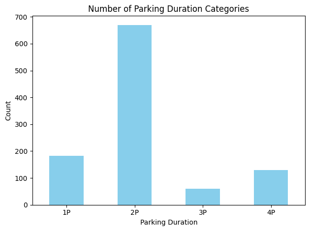

```python
import pandas as pd
import requests
from io import StringIO
import matplotlib.pyplot as plt

# API details for 'sign-plates-located-in-each-parking-zone-copy'
base_url = 'https://data.melbourne.vic.gov.au/api/explore/v2.1/catalog/datasets/'
dataset_id = 'sign-plates-located-in-each-parking-zone-copy'

# Fetch the dataset from the API
url = f"{base_url}{dataset_id}/exports/csv"
response = requests.get(url)
df = pd.read_csv(StringIO(response.text), delimiter=';')

# Step 1: Print all column names to identify the correct column for parking zones
print("Column Names in the Dataset:")
print(df.columns.tolist())

# Step 2: Once the correct column name is identified, replace 'ParkingZone' with the actual column name
correct_column_name = 'parkingzone'  # Replace with actual column name if different
restriction_column = 'restriction_display'  # Replace with actual column name if different

# Define a function to categorize parking zones based on 'restriction_display'
def categorize_parking(restriction_display):
    if pd.isnull(restriction_display):
        return 'Unknown'
    elif '1P' in restriction_display:
        return '1P'
    elif '2P' in restriction_display:
        return '2P'
    elif '3P' in restriction_display:
        return '3P'
    elif '4P' in restriction_display:
        return '4P'
    else:
        return 'Other'

# Apply the categorization function to the 'restriction_display' column
if restriction_column in df.columns:
    df['Parking_Category'] = df[restriction_column].apply(categorize_parking)

    # Step 3: Print the first few rows of the categorized dataset
    print("\nParking Zones categorized by restriction display:")
    print(df[[correct_column_name, restriction_column, 'Parking_Category']].head())

    # Step 4: Count how many 1P, 2P, 3P, and 4P categories there are
    category_counts = df['Parking_Category'].value_counts()

    print("\nCount of Parking Categories:")
    print(category_counts[['1P', '2P', '3P', '4P']].fillna(0))  # Fill with 0 if any category is missing

    # Step 5: Plot the bar graph
    category_counts[['1P', '2P', '3P', '4P']].fillna(0).plot(kind='bar', color='skyblue')
    plt.title('Number of Parking Duration Categories')
    plt.xlabel('Parking Duration')
    plt.ylabel('Count')
    plt.xticks(rotation=0)
    plt.tight_layout()
    plt.show()

else:
    print(f"\nColumn '{restriction_column}' not found in the dataset.")
```

### 12.7. Correlation Analysis

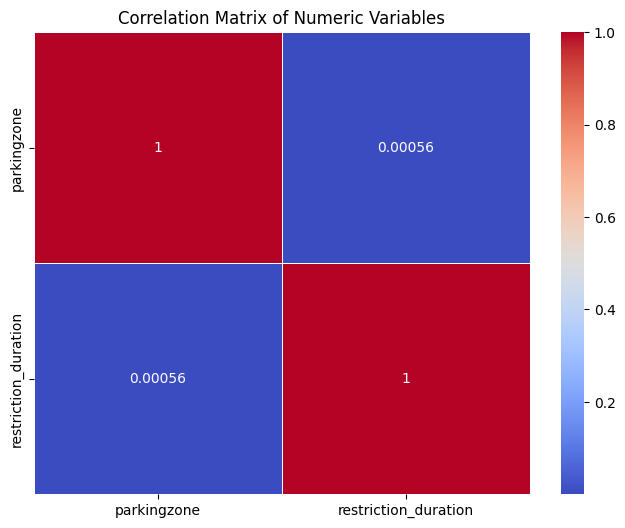

```python
import pandas as pd
import numpy as np
import matplotlib.pyplot as plt
import seaborn as sns

# Convert any time-related columns to datetime, handling any issues in conversion
df['time_restrictions_start'] = pd.to_datetime(df['time_restrictions_start'], errors='coerce')
df['time_restrictions_finish'] = pd.to_datetime(df['time_restrictions_finish'], errors='coerce')

# Ensure both columns have valid datetime values before performing the subtraction
valid_mask = df['time_restrictions_start'].notnull() & df['time_restrictions_finish'].notnull()

# Create a restriction duration column (in hours) where valid values exist
df.loc[valid_mask, 'restriction_duration'] = (
    (df['time_restrictions_finish'] - df['time_restrictions_start']).dt.total_seconds() / 3600
)

# Perform correlation analysis on numeric columns
numeric_columns = df.select_dtypes(include=[np.number])

# Check if the numeric columns contain any valid data
if not numeric_columns.empty:
    correlation_matrix = numeric_columns.corr()

    # Visualize the correlation matrix
    plt.figure(figsize=(8, 6))
    sns.heatmap(correlation_matrix, annot=True, cmap='coolwarm', linewidths=0.5)
    plt.title('Correlation Matrix of Numeric Variables')
    plt.show()
else:
    print("No numeric columns available for correlation analysis.")
```

### 12.8. Filtering and Finding Specific Zones

filter zones based on specific conditions, such as zones with restrictions on weekends, or zones with long restriction durations.

```
Column Names in the Dataset:
['parkingzone', 'restriction_days', 'time_restrictions_start', 'time_restrictions_finish', 'restriction_display']

Zones with restrictions on weekends:
   parkingzone restriction_days restriction_display
2         7449          Mon-Sat                  2P
3         7450          Sat-Sun                  2P
5         7452          Sat-Sun                  2P
6         7454          Sat-Sun                  2P
7         7471              Sat                  2P

Zones with restriction durations longer than 2 hours:
   parkingzone restriction_days restriction_display
0         7445          Mon-Fri                  2P
1         7446          Mon-Fri                  2P
2         7449          Mon-Sat                  2P
3         7450          Sat-Sun                  2P
4         7452          Mon-Fri                  2P
```

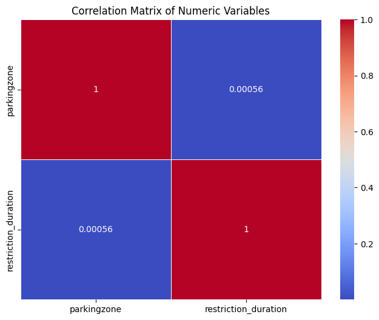

```python
import pandas as pd
import requests
from io import StringIO
import matplotlib.pyplot as plt
import seaborn as sns

# API details for 'sign-plates-located-in-each-parking-zone-copy'
base_url = 'https://data.melbourne.vic.gov.au/api/explore/v2.1/catalog/datasets/'
dataset_id = 'sign-plates-located-in-each-parking-zone-copy'

# Fetch the dataset from the API
url = f"{base_url}{dataset_id}/exports/csv"
response = requests.get(url)
df = pd.read_csv(StringIO(response.text), delimiter=';')

# Step 1: Print column names to inspect the data
print("Column Names in the Dataset:")
print(df.columns.tolist())

# Convert any time-related columns to datetime, handling any issues in conversion
df['time_restrictions_start'] = pd.to_datetime(df['time_restrictions_start'], errors='coerce')
df['time_restrictions_finish'] = pd.to_datetime(df['time_restrictions_finish'], errors='coerce')

# Ensure both columns have valid datetime values before performing the subtraction
valid_mask = df['time_restrictions_start'].notnull() & df['time_restrictions_finish'].notnull()

# Create a restriction duration column (in hours) where valid values exist
df.loc[valid_mask, 'restriction_duration'] = (
    (df['time_restrictions_finish'] - df['time_restrictions_start']).dt.total_seconds() / 3600
)

# Step 2: Filter zones with restrictions on weekends
# Catch any rows with 'Sat', 'Sun', 'Sat-Sun', etc. in the 'restriction_days' column
weekend_zones = df[df['restriction_days'].str.contains('Sat|Sun', na=False)]
print("\nZones with restrictions on weekends:")
print(weekend_zones[['parkingzone', 'restriction_days', 'restriction_display']].head())

# Step 3: Filter zones with longer restriction durations (e.g., 2P, 3P, or 4P)
long_restriction_zones = df[df['restriction_display'].str.contains('2P|3P|4P', na=False)]
print("\nZones with restriction durations longer than 2 hours:")
print(long_restriction_zones[['parkingzone', 'restriction_days', 'restriction_display']].head())

# Optional: Perform correlation analysis on numeric columns
numeric_columns = df.select_dtypes(include=[float, int])

# Check if the numeric columns contain any valid data
if not numeric_columns.empty:
    correlation_matrix = numeric_columns.corr()

    # Visualize the correlation matrix
    plt.figure(figsize=(8, 6))
    sns.heatmap(correlation_matrix, annot=True, cmap='coolwarm', linewidths=0.5)
    plt.title('Correlation Matrix of Numeric Variables')
    plt.show()
else:
    print("No numeric columns available for correlation analysis.")
```

```python
import pandas as pd
import requests
from io import StringIO

# API details for the first dataset: 'sign-plates-located-in-each-parking-zone-copy'
base_url_1 = 'https://data.melbourne.vic.gov.au/api/explore/v2.1/catalog/datasets/'
dataset_id_1 = 'sign-plates-located-in-each-parking-zone-copy'
url_1 = f"{base_url_1}{dataset_id_1}/exports/csv"

# Fetch the first dataset (Parking Zones dataset)
response_1 = requests.get(url_1)
df_1 = pd.read_csv(StringIO(response_1.text), delimiter=';')

# API details for the second dataset: 'on-street-parking-bay-sensors'
base_url_2 = 'https://data.melbourne.vic.gov.au/api/explore/v2.1/catalog/datasets/'
dataset_id_2 = 'on-street-parking-bay-sensors'
url_2 = f"{base_url_2}{dataset_id_2}/exports/csv"

# Fetch the second dataset (Parking Bay Sensors dataset)
response_2 = requests.get(url_2)
df_2 = pd.read_csv(StringIO(response_2.text), delimiter=';')

# Step 1: Inspect column names from both datasets
print("Column Names in 'sign-plates-located-in-each-parking-zone-copy' dataset:")
print(df_1.columns.tolist())
print("\nColumn Names in 'on-street-parking-bay-sensors' dataset:")
print(df_2.columns.tolist())

# Step 2: Extract the 'ParkingZone' column from the first dataset (df_1)
# Replace 'ParkingZone' with the actual column name if different
if 'parkingzone' in df_1.columns:
    parking_zones = df_1['parkingzone'].dropna().unique()
else:
    print("Column 'ParkingZone' not found in the first dataset.")
    parking_zones = []

# Step 3: Filter the second dataset (df_2) based on the extracted 'ParkingZone' values
# Replace 'zone_number' with the actual column name in the second dataset if different
if 'zone_number' in df_2.columns:
    filtered_df_2 = df_2[df_2['zone_number'].isin(parking_zones)]
else:
    print("Column 'zone_number' not found in the second dataset.")
    filtered_df_2 = pd.DataFrame()

# Step 4: Print the first few rows of the filtered dataset
print("\nFiltered data from 'on-street-parking-bay-sensors' based on 'ParkingZone':")
print(filtered_df_2.head())

# Step 5: Perform any desired analysis on the filtered dataset (optional)
# Example: Count the number of entries per zone
zone_count = filtered_df_2['zone_number'].value_counts()
print("\nCount of entries per 'zone_number':")
print(zone_count.head())
```

```
Column Names in 'sign-plates-located-in-each-parking-zone-copy' dataset:
['parkingzone', 'restriction_days', 'time_restrictions_start', 'time_restrictions_finish', 'restriction_display']

Column Names in 'on-street-parking-bay-sensors' dataset:
['lastupdated', 'status_timestamp', 'zone_number', 'status_description', 'kerbsideid', 'location']

Filtered data from 'on-street-parking-bay-sensors' based on 'ParkingZone':
                 lastupdated           status_timestamp  zone_number  \
0  2023-12-14T04:45:34+00:00  2023-12-14T03:41:25+00:00       7695.0
1  2023-12-14T04:45:34+00:00  2023-12-13T06:21:58+00:00       7939.0
4  2023-12-18T04:45:34+00:00  2023-12-17T23:47:54+00:00       7310.0
5  2023-12-18T04:45:34+00:00  2023-11-02T00:47:52+00:00       7050.0
6  2023-12-18T04:45:34+00:00  2023-12-18T04:03:50+00:00       7310.0

  status_description  kerbsideid                                 location
0         Unoccupied       22959   -37.81844776554182, 144.95938672872117
1         Unoccupied       10136    -37.8099909364941, 144.95263753679632
4         Unoccupied        6497   -37.81044576734748, 144.95648958199024
5            Present        8958   -37.80588632122739, 144.95989190405095
6         Unoccupied       25139  -37.810361269606986, 144.95724275778542

Count of entries per 'zone_number':
zone_number
7566.0    96
7833.0    84
7250.0    76
7025.0    70
7556.0    68
Name: count, dtype: int64
```

## 13. Use two API Datasets to make calculation

Use the zone_number column from the API dataset_id_2 = 'on-street-parking-bay-sensors' and use this column values to find the calculation of the total count of parkingzones in the dataset dataset_id_1 = 'sign-plates-located-in-each-parking-zone-copy

```python
import pandas as pd
import requests
from io import StringIO

# API details for the first dataset: 'sign-plates-located-in-each-parking-zone-copy'
base_url_1 = 'https://data.melbourne.vic.gov.au/api/explore/v2.1/catalog/datasets/'
dataset_id_1 = 'sign-plates-located-in-each-parking-zone-copy'
url_1 = f"{base_url_1}{dataset_id_1}/exports/csv"

# Fetch the first dataset (Parking Zones dataset)
response_1 = requests.get(url_1)
df_1 = pd.read_csv(StringIO(response_1.text), delimiter=';')

# API details for the second dataset: 'on-street-parking-bay-sensors'
base_url_2 = 'https://data.melbourne.vic.gov.au/api/explore/v2.1/catalog/datasets/'
dataset_id_2 = 'on-street-parking-bay-sensors'
url_2 = f"{base_url_2}{dataset_id_2}/exports/csv"

# Fetch the second dataset (Parking Bay Sensors dataset)
response_2 = requests.get(url_2)
df_2 = pd.read_csv(StringIO(response_2.text), delimiter=';')

# Step 1: Inspect column names from both datasets
print("Column Names in 'sign-plates-located-in-each-parking-zone-copy' dataset:")
print(df_1.columns.tolist())
print("\nColumn Names in 'on-street-parking-bay-sensors' dataset:")
print(df_2.columns.tolist())

# Step 2: Extract the 'ParkingZone' column from the first dataset (df_1)
# Replace 'ParkingZone' with the actual column name if different
if 'parkingzone' in df_1.columns:
    parking_zones = df_1['parkingzone'].dropna().unique()
else:
    print("Column 'ParkingZone' not found in the first dataset.")
    parking_zones = []

# Step 3: Filter the second dataset (df_2) based on the extracted 'ParkingZone' values
# Replace 'zone_number' with the actual column name in the second dataset if different
if 'zone_number' in df_2.columns:
    filtered_df_2 = df_2[df_2['zone_number'].isin(parking_zones)]
else:
    print("Column 'zone_number' not found in the second dataset.")
    filtered_df_2 = pd.DataFrame()

# Step 4: Print the first few rows of the filtered dataset
print("\nFiltered data from 'on-street-parking-bay-sensors' based on 'ParkingZone':")
print(filtered_df_2.head())

# Step 5: Perform any desired analysis on the filtered dataset (optional)
# Example: Count the number of entries per zone
zone_count = filtered_df_2['zone_number'].value_counts()
print("\nCount of entries per 'zone_number':")
print(zone_count.head())
```

```
Column Names in 'sign-plates-located-in-each-parking-zone-copy' dataset:
['parkingzone', 'restriction_days', 'time_restrictions_start', 'time_restrictions_finish', 'restriction_display']

Column Names in 'on-street-parking-bay-sensors' dataset:
['lastupdated', 'status_timestamp', 'zone_number', 'status_description', 'kerbsideid', 'location']

Filtered data from 'on-street-parking-bay-sensors' based on 'ParkingZone':
                 lastupdated           status_timestamp  zone_number  \
0  2023-12-14T04:45:34+00:00  2023-12-14T03:41:25+00:00       7695.0
1  2023-12-14T04:45:34+00:00  2023-12-13T06:21:58+00:00       7939.0
4  2023-12-18T04:45:34+00:00  2023-12-17T23:47:54+00:00       7310.0
5  2023-12-18T04:45:34+00:00  2023-11-02T00:47:52+00:00       7050.0
6  2023-12-18T04:45:34+00:00  2023-12-18T04:03:50+00:00       7310.0

  status_description  kerbsideid                                 location
0         Unoccupied       22959   -37.81844776554182, 144.95938672872117
1         Unoccupied       10136    -37.8099909364941, 144.95263753679632
4         Unoccupied        6497   -37.81044576734748, 144.95648958199024
5            Present        8958   -37.80588632122739, 144.95989190405095
6         Unoccupied       25139  -37.810361269606986, 144.95724275778542

Count of entries per 'zone_number':
zone_number
7566.0    96
7833.0    84
7250.0    76
7025.0    70
7556.0    68
Name: count, dtype: int64
```

### 13.1. Using two datasets from APIs

For calculating the parked vehicles currently according to parkingzone column in dataset dataset_id_1 = 'sign-plates-located-in-each-parking-zone-copy'.

```python
import pandas as pd
import requests
from io import StringIO

# API details for the first dataset: 'sign-plates-located-in-each-parking-zone-copy'
base_url_1 = 'https://data.melbourne.vic.gov.au/api/explore/v2.1/catalog/datasets/'
dataset_id_1 = 'sign-plates-located-in-each-parking-zone-copy'
url_1 = f"{base_url_1}{dataset_id_1}/exports/csv"

# Fetch the first dataset (Parking Zones dataset)
response_1 = requests.get(url_1)
df_1 = pd.read_csv(StringIO(response_1.text), delimiter=';')

# API details for the second dataset: 'on-street-parking-bay-sensors'
base_url_2 = 'https://data.melbourne.vic.gov.au/api/explore/v2.1/catalog/datasets/'
dataset_id_2 = 'on-street-parking-bay-sensors'
url_2 = f"{base_url_2}{dataset_id_2}/exports/csv"

# Fetch the second dataset (Parking Bay Sensors dataset)
response_2 = requests.get(url_2)
df_2 = pd.read_csv(StringIO(response_2.text), delimiter=';')

# Step 1: Inspect column names from both datasets
print("Column Names in 'sign-plates-located-in-each-parking-zone-copy' dataset:")
print(df_1.columns.tolist())
print("\nColumn Names in 'on-street-parking-bay-sensors' dataset:")
print(df_2.columns.tolist())

# Step 2: Extract the 'ParkingZone' column from the first dataset (df_1)
# Replace 'parkingzone' with the actual column name if different
if 'parkingzone' in df_1.columns:
    parking_zones = df_1['parkingzone'].dropna().unique()
else:
    print("Column 'ParkingZone' not found in the first dataset.")
    parking_zones = []

#. Step 3: Filter the second dataset (df_2) based on the extracted 'ParkingZone' values
# Replace 'zone_number' and 'status_description' with the actual column names in the second dataset if different
if 'zone_number' in df_2.columns and 'status_description' in df_2.columns:
    # Filter the second dataset to get only the rows where vehicles are currently parked (status_description == 'Present')
    filtered_df_2 = df_2[(df_2['zone_number'].isin(parking_zones)) & (df_2['status_description'] == 'Present')]
else:
    print("Required columns 'zone_number' or 'status_description' not found in the second dataset.")
    filtered_df_2 = pd.DataFrame()

# Step 4: Calculate the number of parked vehicles for each ParkingZone
if not filtered_df_2.empty:
    parked_vehicles_by_zone = filtered_df_2['zone_number'].value_counts()
    print("\nNumber of currently parked vehicles by 'ParkingZone':")
    print(parked_vehicles_by_zone.head())  # Print the first few results
else:
    print("No data available for parked vehicles.")

# Step 5: Optional - Merge this data back with the first dataset if needed
df_1_with_parked_vehicles = pd.merge(df_1, parked_vehicles_by_zone.rename('Parked_Vehicles'), left_on='parkingzone', right_index=True, how='left')
print("\nFirst few rows of 'sign-plates-located-in-each-parking-zone-copy' dataset with parked vehicles:")
print(df_1_with_parked_vehicles.head())
```

```
Column Names in 'sign-plates-located-in-each-parking-zone-copy' dataset:
['parkingzone', 'restriction_days', 'time_restrictions_start', 'time_restrictions_finish', 'restriction_display']

Column Names in 'on-street-parking-bay-sensors' dataset:
['lastupdated', 'status_timestamp', 'zone_number', 'status_description', 'kerbsideid', 'location']

Number of currently parked vehicles by 'ParkingZone':
zone_number
7556.0    54
7566.0    49
7034.0    48
7833.0    40
7178.0    37
Name: count, dtype: int64

First few rows of 'sign-plates-located-in-each-parking-zone-copy' dataset with parked vehicles:
   parkingzone restriction_days time_restrictions_start  \
0         7445          Mon-Fri                16:00:00
1         7446          Mon-Fri                16:00:00
2         7449          Mon-Sat                07:30:00
3         7450          Sat-Sun                07:00:00
4         7452          Mon-Fri                16:00:00

  time_restrictions_finish restriction_display  Parked_Vehicles
0                 20:30:00                  2P              2.0
1                 22:00:00                  2P              1.0
2                 20:30:00                  2P             27.0
3                 22:00:00                  2P              4.0
4                 22:00:00                  2P              4.0
```

## 14. User Behaviour Analysis

User behaviour analysis mostly depends on the completeness of the datasets. For understanding the user's habits, and daily behaviour, it is required to know about some of the details of the user. One of the important property is the user's vehicle registration number. This helps to track the vehicle such as when he usually does parking or where he prefers to park. In addition to this, if the driver uses the car parking app, and can give some of the details about himself/herself, such as why he/she comes to city to park, when he prefers to drive and park (in which weather condition>) and also parking violation data can be accessible if the vehicle can be tracked. So in this project, under user behaviour analysis, only the given features were used with the provided datasets. So analysis in this title were restricted with the dataset features.

### 14.1. Parking Space Utilization

```python
import pandas as pd
import pytz
from datetime import datetime, timedelta

if not pd.api.types.is_datetime64_dtype(df['lastupdated']):
    try:
        # Attempt conversion if possible
        df['lastupdated'] = pd.to_datetime(df['lastupdated'])
    except (ValueError, pandas.errors.ParserError):
        print("Error: 'lastupdated' column could not be converted to datetime format.")

# 2. Get current time in Australia/Melbourne timezone (adjust if needed)
current_time_melbourne = datetime.now(pytz.timezone('Australia/Melbourne'))

# 3. Calculate the threshold for the last hour
last_hour_threshold = current_time_melbourne - timedelta(hours=1)

# 4. Filter the DataFrame
df_last_hour = df[df['lastupdated'] >= last_hour_threshold]

# Now 'df_last_hour' contains rows with 'lastupdated' within the last hour
print(df_last_hour)
```

[output not shown]

### 14.2 Analyzing Parking Bay Utilization Rates by Kerbside ID

This code fetches real-time parking sensor data from Melbourne's open API and processes it to calculate parking bay utilization rates. It begins by loading the dataset and converting the lastupdated column to a timezone-aware datetime format (UTC). Data is then filtered to include only the past day's records. By grouping data by kerbsideid and analyzing the status_description column, the utilization rate is calculated as the percentage of time each parking bay was occupied. This analysis helps assess parking demand efficiently.

```python
import pandas as pd
import requests
from io import StringIO
import pytz
from datetime import datetime, timedelta

# API details
base_url = 'https://data.melbourne.vic.gov.au/api/explore/v2.1/catalog/datasets/'
dataset_id = 'on-street-parking-bay-sensors'

# Fetch the dataset from the API
url = f"{base_url}{dataset_id}/exports/csv"
response = requests.get(url)
df = pd.read_csv(StringIO(response.text), delimiter=';')

# Convert 'lastupdated' to datetime, assuming UTC timezone
df['lastupdated'] = pd.to_datetime(df['lastupdated'], utc=True)

# Filter for the last day (adjust time range as needed)
last_day = datetime.now(pytz.timezone('Australia/Melbourne')) - timedelta(days=1)
df_last_day = df[df['lastupdated'] >= last_day]

# Group by kerbside_id and calculate utilization rate
kerbside_utilization = df_last_day.groupby('kerbsideid')['status_description'].apply(
    lambda x: (x == 'occupied').mean() * 100
).reset_index(name='utilization_rate')

# Print the results
print(kerbside_utilization)
```

```
      kerbsideid  utilization_rate
0           5691               0.0
1           5706               0.0
2           5726               0.0
3           5734               0.0
4           5736               0.0
...          ...               ...
3291       69976               0.0
3292       69977               0.0
3293       69978               0.0
3294       69979               0.0
3295       90812               0.0

[3296 rows x 2 columns]
```

### 14.3. Fetching for Parking Zone Utilization - Number of the Parked Vehicles by Zone

This code fetches two datasets from Melbourne's open data portal: one detailing parking zone sign plates and another providing on-street parking sensor information. After importing the necessary libraries, it loads both datasets into pandas DataFrames. The code filters the sensor data to include only currently occupied parking bays (status_description equals 'Present'). It then counts the number of parked vehicles in each parking zone by using the 'zone_number' field. Finally, it prints out the number of parked vehicles per parking zone, offering insights into parking utilization across different areas.

```python
import pandas as pd
import requests
from io import StringIO

# Fetch Dataset 1: Parking Zone Sign Plates
base_url_1 = 'https://data.melbourne.vic.gov.au/api/explore/v2.1/catalog/datasets/'
dataset_id_1 = 'sign-plates-located-in-each-parking-zone-copy'
url_1 = f"{base_url_1}{dataset_id_1}/exports/csv"
response_1 = requests.get(url_1)
df_1 = pd.read_csv(StringIO(response_1.text), delimiter=';')

# Fetch Dataset 2: On-Street Parking Sensors
base_url_2 = 'https://data.melbourne.vic.gov.au/api/explore/v2.1/catalog/datasets/'
dataset_id_2 = 'on-street-parking-bay-sensors'
url_2 = f"{base_url_2}{dataset_id_2}/exports/csv"
response_2 = requests.get(url_2)
df_2 = pd.read_csv(StringIO(response_2.text), delimiter=';')

# Calculate number of parked vehicles by parking zone
parked_vehicles = df_2[df_2['status_description'] == 'Present']
parked_vehicles_by_zone = parked_vehicles['zone_number'].value_counts()

print("Number of parked vehicles by parking zone:")
print(parked_vehicles_by_zone)
```

```
Number of parked vehicles by parking zone:
zone_number
7556.0    54
7566.0    49
7034.0    48
7833.0    40
7570.0    38
          ..
7685.0     1
7927.0     1
7681.0     1
7133.0     1
7020.0     1
Name: count, Length: 466, dtype: int64
```

### 14.4. Calculating Parking Zone Utilization Rates

```python
import pandas as pd
import requests
from io import StringIO

# Fetch Dataset 1: Parking Zone Sign Plates
base_url_1 = 'https://data.melbourne.vic.gov.au/api/explore/v2.1/catalog/datasets/'
dataset_id_1 = 'sign-plates-located-in-each-parking-zone-copy'
url_1 = f"{base_url_1}{dataset_id_1}/exports/csv"
response_1 = requests.get(url_1)
df_1 = pd.read_csv(StringIO(response_1.text), delimiter=';')

# Fetch Dataset 2: On-Street Parking Sensors
base_url_2 = 'https://data.melbourne.vic.gov.au/api/explore/v2.1/catalog/datasets/'
dataset_id_2 = 'on-street-parking-bay-sensors'
url_2 = f"{base_url_2}{dataset_id_2}/exports/csv"
response_2 = requests.get(url_2)
df_2 = pd.read_csv(StringIO(response_2.text), delimiter=';')

# Example total bays data
total_bays = {'7556.0': 50, '7566.0': 40, '7034.0': 35}  # Replace with real data
df_1['total_bays'] = df_1['parkingzone'].apply(lambda x: total_bays.get(x, 10))  # Default 10 bays

# Merge parked vehicle counts into the first dataset
parked_vehicles = df_2[df_2['status_description'] == 'Present']
parked_vehicles_by_zone = parked_vehicles['zone_number'].value_counts()
df_1 = pd.merge(df_1, parked_vehicles_by_zone.rename('Parked_Vehicles'), left_on='parkingzone', right_index=True, how='left')

# Calculate utilization rates
df_1['Utilization_Rate'] = (df_1['Parked_Vehicles'] / df_1['total_bays']) * 100
print("Parking Zone Utilization Rates:")
print(df_1[['parkingzone', 'Utilization_Rate']])
```

```
Parking Zone Utilization Rates:
      parkingzone  Utilization_Rate
0            7445              20.0
1            7446              20.0
2            7449             270.0
3            7450              50.0
4            7452              30.0
...           ...               ...
1153         7433               NaN
1154         7434              40.0
1155         7436              60.0
1156         7440               NaN
1157         7441              10.0

[1158 rows x 2 columns]
```

### 14.5. Identifying Peak Parking Times

```python
import pandas as pd
import requests
from io import StringIO

# Fetch Dataset 2: On-Street Parking Sensors
base_url_2 = 'https://data.melbourne.vic.gov.au/api/explore/v2.1/catalog/datasets/'
dataset_id_2 = 'on-street-parking-bay-sensors'
url_2 = f"{base_url_2}{dataset_id_2}/exports/csv"
response_2 = requests.get(url_2)
df_2 = pd.read_csv(StringIO(response_2.text), delimiter=';')

# Convert timestamps to datetime and extract hours
df_2['status_timestamp'] = pd.to_datetime(df_2['status_timestamp'], errors='coerce')
df_2['hour'] = df_2['status_timestamp'].dt.hour

# Group by hour to identify peak times
peak_hours = df_2[df_2['status_description'] == 'Present'].groupby('hour').size()
print("Peak parking times (number of parked vehicles by hour):")
print(peak_hours)
```

```
Peak parking times (number of parked vehicles by hour):
hour
0     233
1     236
2     202
3     160
4     120
5     154
6     277
7     368
8     495
9     556
10     37
11     20
12     26
13     10
14     12
15      7
16     11
17      4
18     13
19     38
20     59
21     85
22    154
23    210
dtype: int64
```

```python
import pandas as pd
import requests
from io import StringIO

# Fetch Dataset 2: On-Street Parking Sensors
base_url_2 = 'https://data.melbourne.vic.gov.au/api/explore/v2.1/catalog/datasets/'
dataset_id_2 = 'on-street-parking-bay-sensors'
url_2 = f"{base_url_2}{dataset_id_2}/exports/csv"
response_2 = requests.get(url_2)
df_2 = pd.read_csv(StringIO(response_2.text), delimiter=';')

# Filter rows where vehicles are currently parked
parked_vehicles = df_2[df_2['status_description'] == 'Present']

# Total number of parking events
total_parking_events = len(parked_vehicles)

# Number of unique parking zones with parked vehicles
unique_zones = parked_vehicles['zone_number'].nunique()

# Parking counts by zone
parking_counts_by_zone = parked_vehicles['zone_number'].value_counts()

# Average and maximum number of parked vehicles per zone
average_parked_vehicles = parking_counts_by_zone.mean()
max_parked_vehicles = parking_counts_by_zone.max()
zone_with_max_vehicles = parking_counts_by_zone.idxmax()

# Output statistical information
print("Statistical Information:")
print(f"Total number of parking events: {total_parking_events}")
print(f"Number of unique parking zones: {unique_zones}")
print(f"Average number of parked vehicles per zone: {average_parked_vehicles:.2f}")
print(f"Maximum number of parked vehicles in a single zone: {max_parked_vehicles}")
print(f"Zone with the maximum parked vehicles: {zone_with_max_vehicles}")
print("\nParking Counts by Zone (Top 10):")
print(parking_counts_by_zone.head(10))
```

```
Statistical Information:
Total number of parking events: 1368
Number of unique parking zones: 258
Average number of parked vehicles per zone: 4.95
Maximum number of parked vehicles in a single zone: 22
Zone with the maximum parked vehicles: 7556.0

Parking Counts by Zone (Top 10):
zone_number
7556.0    22
7725.0    21
7634.0    19
7178.0    18
7721.0    18
7551.0    17
7549.0    16
7639.0    16
7571.0    16
7605.0    16
Name: count, dtype: int64
```

### 14.7. Total Parked Vehicles by Kerbside ID without defining exact dates

```python
import pandas as pd
import requests
from io import StringIO

# Fetch Dataset 2: On-Street Parking Sensors
base_url_2 = 'https://data.melbourne.vic.gov.au/api/explore/v2.1/catalog/datasets/'
dataset_id_2 = 'on-street-parking-bay-sensors'
url_2 = f"{base_url_2}{dataset_id_2}/exports/csv"
response_2 = requests.get(url_2)
df_2 = pd.read_csv(StringIO(response_2.text), delimiter=';')

# Filter rows where vehicles are currently parked
parked_vehicles = df_2[df_2['status_description'] == 'Present'].copy()

# Calculate total parked vehicles for each kerbsideid
total_parked_by_kerbside = parked_vehicles.groupby('kerbsideid').size().reset_index(name='total_parked_vehicles')

# Sort by total parked vehicles in descending order
total_parked_by_kerbside = total_parked_by_kerbside.sort_values(by='total_parked_vehicles', ascending=False)

# Output the results
print("Total Parked Vehicles by Kerbside ID:")
print(total_parked_by_kerbside)
```

```
Total Parked Vehicles by Kerbside ID:
      kerbsideid  total_parked_vehicles
0           5736                      1
909        60132                      1
917        60425                      1
916        60424                      1
915        60230                      1
...          ...                    ...
454        20581                      1
453        20578                      1
452        20577                      1
451        20576                      1
1367       69977                      1

[1368 rows x 2 columns]
```

### 14.8. Daily Parked Vehicles by Kerbside ID for the Last 7 Days (from 2024-11-25 to 2024-12-02)

Behavioral Analysis

```python
import pandas as pd
import requests
from io import StringIO
from datetime import datetime, timedelta

# Fetch Dataset 2: On-Street Parking Sensors
base_url_2 = 'https://data.melbourne.vic.gov.au/api/explore/v2.1/catalog/datasets/'
dataset_id_2 = 'on-street-parking-bay-sensors'
url_2 = f"{base_url_2}{dataset_id_2}/exports/csv"
response_2 = requests.get(url_2)
df_2 = pd.read_csv(StringIO(response_2.text), delimiter=';')

# Filter rows where vehicles are currently parked
parked_vehicles = df_2[df_2['status_description'] == 'Present'].copy()

# Convert timestamp column to datetime
parked_vehicles['status_timestamp'] = pd.to_datetime(parked_vehicles['status_timestamp'])

# Extract the date from the timestamp
parked_vehicles['date'] = parked_vehicles['status_timestamp'].dt.date

# Define the last 7 days
today = datetime.today().date()
last_week_start = today - timedelta(days=7)

# Filter data for the last 7 days
last_week_data = parked_vehicles[parked_vehicles['date'] >= last_week_start]

# Group data by date and kerbsideid for daily parked vehicle counts
daily_kerbside_report = last_week_data.groupby(['date', 'kerbsideid']).size().reset_index(name='daily_parked_vehicle_count')

# Group data by kerbsideid for total parked vehicle counts across the dataset
total_parked_by_kerbside = parked_vehicles.groupby('kerbsideid').size().reset_index(name='total_parked_vehicles')

# Sort daily report by date and kerbsideid
daily_kerbside_report = daily_kerbside_report.sort_values(by=['date', 'kerbsideid'])

# Sort total parked vehicles by kerbsideid
total_parked_by_kerbside = total_parked_by_kerbside.sort_values(by='total_parked_vehicles', ascending=False)

# Output the daily report for the last 7 days
print(f"Daily Parked Vehicles by Kerbside ID for the Last 7 Days (from {last_week_start} to {today}):")
for date in daily_kerbside_report['date'].unique():
    print(f"\nDate: {date}")
    date_data = daily_kerbside_report[daily_kerbside_report['date'] == date]
    print(date_data[['kerbsideid', 'daily_parked_vehicle_count']])

# Output the total parked vehicles across the dataset
print("\nTotal Parked Vehicles by Kerbside ID Across the Dataset:")
print(total_parked_by_kerbside)

import tkinter as tk

def run_code():
    label.config(text="Code is running!")

# Create the main application window
root = tk.Tk()
root.title("Run Code")
root.geometry("200x100")

# Add a label and a button
label = tk.Label(root, text="Click the button to run code.")
label.pack(pady=10)
run_button = tk.Button(root, text="Run Code", command=run_code)
run_button.pack(pady=10)

# Start the GUI loop
root.mainloop()
```

```
Daily Parked Vehicles by Kerbside ID for the Last 7 Days (from 2024-11-25 to 2024-12-02):

Date: 2024-11-26
   kerbsideid  daily_parked_vehicle_count
0       12093                           1
1       24368                           1

Date: 2024-11-27
   kerbsideid  daily_parked_vehicle_count
2       24369                           1
3       24423                           1

Date: 2024-11-28
    kerbsideid  daily_parked_vehicle_count
4         8729                           1
5         8731                           1
6         8733                           1
7         8734                           1
8         8735                           1
9         8738                           1
10        8750                           1
11        8752                           1
12        8754                           1
13       24044                           1

Date: 2024-11-29
    kerbsideid  daily_parked_vehicle_count
14       10296                           1
15       10717                           1
16       10727                           1
17       10732                           1
18       11264                           1
19       12125                           1
20       57316                           1
21       58119                           1

Date: 2024-11-30
    kerbsideid  daily_parked_vehicle_count
22       10287                           1
23       10722                           1
```

[output cut: 41 more lines]

```
Total Parked Vehicles by Kerbside ID Across the Dataset:
      kerbsideid  total_parked_vehicles
0           5736                      1
918        57316                      1
926        58119                      1
925        58118                      1
924        58117                      1
...          ...                    ...
459        20576                      1
458        20575                      1
457        20574                      1
456        20573                      1
1380       69978                      1

[1381 rows x 2 columns]
```

## 15. SQL Query Based Operations

### 15.1. Create SQLite database and tables (No Relationship Assignment to the Datasets)

This code combines two parking datasets from Melbourne’s open data. The first dataset lists parking zones and restrictions, while the second shows real-time parking sensor data. Any missing values in both datasets are replaced with default placeholders like "Unknown" or default times like "00:00" to ensure the data is clean.

The code stores the datasets in a temporary SQLite database, allowing us to run queries. Three example queries are shown: (1) retrieving parking zone restrictions, (2) listing unoccupied parking bays, and (3) combining parking zone restrictions with real-time data. This setup makes it easier to explore and analyze how parking restrictions relate to real-time availability.

By cleaning and structuring the data, this approach provides a clear way to manage and query parking information for better decision-making or further analysis.

```python
import requests
import pandas as pd
import sqlite3
from io import StringIO

# API details for the first dataset: 'sign-plates-located-in-each-parking-zone-copy'
base_url_1 = 'https://data.melbourne.vic.gov.au/api/explore/v2.1/catalog/datasets/'
dataset_id_1 = 'sign-plates-located-in-each-parking-zone-copy'
url_1 = f"{base_url_1}{dataset_id_1}/exports/csv"

# API details for the second dataset: 'on-street-parking-bay-sensors'
base_url_2 = 'https://data.melbourne.vic.gov.au/api/explore/v2.1/catalog/datasets/'
dataset_id_2 = 'on-street-parking-bay-sensors'
url_2 = f"{base_url_2}{dataset_id_2}/exports/csv"

# Fetch datasets
response_1 = requests.get(url_1)
df_1 = pd.read_csv(StringIO(response_1.text), delimiter=';')

response_2 = requests.get(url_2)
df_2 = pd.read_csv(StringIO(response_2.text), delimiter=';')

# Fill null values in df_1
df_1.fillna({
    'parkingzone': 'Unknown',  # Replace null parking zones with 'Unknown'
    'restriction_days': 'No Restrictions',  # Replace null restriction days with 'No Restrictions'
    'time_restrictions_start': '00:00',  # Default to midnight for missing time start
    'time_restrictions_finish': '23:59',  # Default to end of day for missing time finish
    'restriction_display': 'No Display'  # Replace null restriction display with 'No Display'
}, inplace=True)

# Fill null values in df_2
df_2.fillna({
    'lastupdated': '1970-01-01T00:00:00',  # Replace null timestamps with a default epoch time
    'status_timestamp': '1970-01-01T00:00:00',  # Replace null status timestamps
    'zone_number': 'Unknown',  # Replace null zone numbers with 'Unknown'
    'status_description': 'Unknown',  # Replace null status descriptions with 'Unknown'
    'kerbsideid': 'Unknown',  # Replace null kerbside IDs with 'Unknown'
    'location': 'Unknown'  # Replace null locations with 'Unknown'
}, inplace=True)

# Create SQLite database and tables
conn = sqlite3.connect(':memory:')
df_1.to_sql('sign_plates_located_in_each_parking_zone', conn, index=False, if_exists='replace')
df_2.to_sql('on_street_parking_bay_sensors', conn, index=False, if_exists='replace')

# Define a function to execute and display SQL queries with explanations
def execute_query_with_explanation(title, explanation, query):
    print(f"\n### {title} ###")
    print(f"{explanation}\n")
    result = pd.read_sql_query(query, conn)
    print(result)
    return result

# Example queries after handling null values
execute_query_with_explanation(
    "Retrieve Parking Zones and Restrictions",
    "This query retrieves parking zones and their restriction details from the sign plates dataset.",
    """
    SELECT parkingzone, restriction_days, time_restrictions_start, time_restrictions_finish
    FROM sign_plates_located_in_each_parking_zone;
    """
)

execute_query_with_explanation(
    "Filter Unoccupied Parking Bays",
    "This query filters out parking sensor data to show unoccupied parking bays with their zone numbers.",
    """
    SELECT kerbsideid, status_description, zone_number
    FROM on_street_parking_bay_sensors
    WHERE status_description = 'Unoccupied';
    """
)

execute_query_with_explanation(
    "Combine Parking Zone Restrictions and Real-Time Status",
    "This query joins both datasets to match parking zone restrictions with the real-time parking status and location.",
    """
    SELECT
        s1.parkingzone,
        s1.restriction_days,
        s2.status_description,
        s2.location
    FROM sign_plates_located_in_each_parking_zone AS s1
    JOIN on_street_parking_bay_sensors AS s2
    ON s1.parkingzone = s2.zone_number;
    """
)

# Close the SQLite connection
conn.close()
```

```
### Retrieve Parking Zones and Restrictions ###
This query retrieves parking zones and their restriction details from the sign plates dataset.

      parkingzone restriction_days time_restrictions_start  \
0            7445          Mon-Fri                16:00:00
1            7446          Mon-Fri                16:00:00
2            7449          Mon-Sat                07:30:00
3            7450          Sat-Sun                07:00:00
4            7452          Mon-Fri                16:00:00
...           ...              ...                     ...
1153         7433              Sat                07:30:00
1154         7434              Sat                18:30:00
1155         7436          Mon-Sun                07:00:00
1156         7440          Mon-Sat                07:30:00
1157         7441              Sat                07:30:00

     time_restrictions_finish
0                    20:30:00
1                    22:00:00
2                    20:30:00
3                    22:00:00
4                    22:00:00
...                       ...
1153                 20:30:00
1154                 20:30:00
1155                 22:00:00
1156                 18:30:00
1157                 20:30:00

[1158 rows x 4 columns]

### Filter Unoccupied Parking Bays ###
This query filters out parking sensor data to show unoccupied parking bays with their zone numbers.

      kerbsideid status_description zone_number
0          50663         Unoccupied      7649.0
1          50664         Unoccupied      7649.0
2          50634         Unoccupied      7649.0
3          50635         Unoccupied      7649.0
4          50640         Unoccupied      7649.0
```

[output cut: 24 more lines]

```

                                     location
0      -37.80908828360667, 144.97187134487461
1      -37.80908828360667, 144.97187134487461
2     -37.809037522981974, 144.97184785392136
3     -37.809037522981974, 144.97184785392136
4      -37.80882551342851, 144.97187528239476
...                                       ...
4560  -37.812934000783684, 144.96245238315606
4561  -37.812063040805526, 144.96267921897072
4562  -37.812063040805526, 144.96267921897072
4563  -37.812063040805526, 144.96267921897072
4564  -37.812063040805526, 144.96267921897072

[4565 rows x 4 columns]
```

### 15.2. SQL + Spatio-Temporal Clustering

Spatio-temporal clustering is a data mining technique used to analyze datasets that contain both spatial (location-based) and temporal (time-based) information. It identifies patterns and groups (clusters) within these datasets by considering both location and time dimensions.

```
Shape of data after SQL query: (2385, 4)
Unique values in 'location':
['-37.80908828360667, 144.97187134487461'
 '-37.809037522981974, 144.97184785392136'
 '-37.80882551342851, 144.97187528239476'
 '-37.808660179978915, 144.97179932080303'
 '-37.808589373656346, 144.97176686270228'
 '-37.810334301158015, 144.96891216705563'
 '-37.813517379359894, 144.95802880213256'
 '-37.81341256173804, 144.95838767338887'
 '-37.813320247143366, 144.9587044311516'
 '-37.813311556984594, 144.95873418423957']
Shape before dropping rows with missing Latitude/Longitude: (2385, 6)
Shape after dropping rows with missing Latitude/Longitude: (2385, 6)
Shape of clustering data before standardization: (2385, 4)
Cluster labels distribution: cluster
0    2323
1      30
2      23
3       9
Name: count, dtype: int64
```

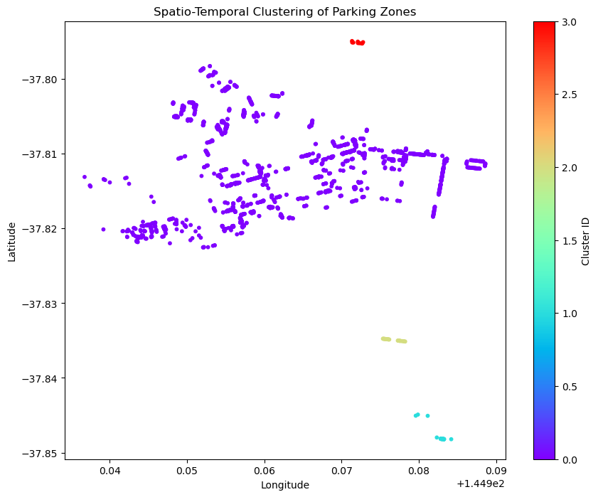

```python
import requests
import pandas as pd
import sqlite3
from io import StringIO
from sklearn.cluster import DBSCAN
from sklearn.preprocessing import StandardScaler
import folium
import matplotlib.pyplot as plt

# Fetch the datasets from the provided APIs
base_url_1 = 'https://data.melbourne.vic.gov.au/api/explore/v2.1/catalog/datasets/'
dataset_id_1 = 'sign-plates-located-in-each-parking-zone-copy'
url_1 = f"{base_url_1}{dataset_id_1}/exports/csv"

base_url_2 = 'https://data.melbourne.vic.gov.au/api/explore/v2.1/catalog/datasets/'
dataset_id_2 = 'on-street-parking-bay-sensors'
url_2 = f"{base_url_2}{dataset_id_2}/exports/csv"

# Fetch the datasets
response_1 = requests.get(url_1)
df_1 = pd.read_csv(StringIO(response_1.text), delimiter=';')

response_2 = requests.get(url_2)
df_2 = pd.read_csv(StringIO(response_2.text), delimiter=';')

# Fill null values in both datasets
df_1.fillna({
    'parkingzone': 'Unknown',
    'restriction_days': 'No Restrictions',
    'time_restrictions_start': '00:00',
    'time_restrictions_finish': '23:59',
    'restriction_display': 'No Display'
}, inplace=True)

df_2.fillna({
    'lastupdated': '1970-01-01T00:00:00',
    'status_timestamp': '1970-01-01T00:00:00',
    'zone_number': 'Unknown',
    'status_description': 'Unknown',
    'kerbsideid': 'Unknown',
    'location': 'Unknown'
}, inplace=True)

# Create an SQLite database
conn = sqlite3.connect(':memory:')
df_1.to_sql('sign_plates_located_in_each_parking_zone', conn, index=False, if_exists='replace')
df_2.to_sql('on_street_parking_bay_sensors', conn, index=False, if_exists='replace')

# SQL query to preprocess and combine data
query = """
SELECT
    s1.parkingzone,
    s1.restriction_days,
    s2.status_description,
    s2.location
FROM sign_plates_located_in_each_parking_zone AS s1
JOIN on_street_parking_bay_sensors AS s2
ON s1.parkingzone = s2.zone_number
WHERE s2.status_description = 'Unoccupied';
"""

# Execute the query and fetch the preprocessed data
preprocessed_data = pd.read_sql_query(query, conn)

# Debugging: Check the shape of the SQL query output
print("Shape of data after SQL query:", preprocessed_data.shape)
if preprocessed_data.empty:
    print("No data returned by the SQL query. Check the filtering conditions.")
    exit()

# Debugging: Check unique values in the 'location' column
print("Unique values in 'location':")
print(preprocessed_data['location'].unique()[:10])  # Print a sample of unique location values

# Split latitude and longitude from the 'location' column
preprocessed_data[['Latitude', 'Longitude']] = preprocessed_data['location'].str.split(',', expand=True).astype(float)

# Debugging: Check the validity of latitude and longitude
print("Shape before dropping rows with missing Latitude/Longitude:", preprocessed_data.shape)
preprocessed_data.dropna(subset=['Latitude', 'Longitude'], inplace=True)
print("Shape after dropping rows with missing Latitude/Longitude:", preprocessed_data.shape)

# Prepare the data for clustering
clustering_data = preprocessed_data[['Latitude', 'Longitude', 'status_description']].copy()
clustering_data['status_description_encoded'] = clustering_data['status_description'].astype('category').cat.codes

# Debugging: Check for empty dataframe
print("Shape of clustering data before standardization:", clustering_data.shape)
if clustering_data.empty:
    print("No valid data for clustering. Check the preprocessing steps.")
    exit()

# Standardize the features for clustering
scaler = StandardScaler()
clustering_features = scaler.fit_transform(clustering_data[['Latitude', 'Longitude', 'status_description_encoded']])

# Apply DBSCAN clustering
dbscan = DBSCAN(eps=0.5, min_samples=5)  # Tune parameters for better clustering
clustering_data['cluster'] = dbscan.fit_predict(clustering_features)

# Debugging: Check the clustering results
print("Cluster labels distribution:", clustering_data['cluster'].value_counts())

# Visualize clusters on a map
melbourne_map = folium.Map(location=[-37.8136, 144.9631], zoom_start=13)
for _, row in clustering_data.iterrows():
    color = 'red' if row['cluster'] == -1 else 'blue'  # Noise points in red
    folium.CircleMarker(
        location=(row['Latitude'], row['Longitude']),
        radius=5,
        color=color,
        fill=True,
        fill_opacity=0.6
    ).add_to(melbourne_map)

# Save the map to an HTML file
melbourne_map.save('spatio_temporal_clustering_fixed.html')

# Plot the clusters for visualization (2D scatter plot)
plt.figure(figsize=(10, 8))
plt.scatter(
    clustering_data['Longitude'],
    clustering_data['Latitude'],
    c=clustering_data['cluster'],
    cmap='rainbow',
    s=10
)
plt.title('Spatio-Temporal Clustering of Parking Zones')
plt.xlabel('Longitude')
plt.ylabel('Latitude')
plt.colorbar(label='Cluster ID')
plt.show()
```

### 15.3. Merge the Dataset Columns using for SQL Queries

```python
import requests
import pandas as pd
from io import StringIO

# Fetch the datasets from the provided APIs
base_url_1 = 'https://data.melbourne.vic.gov.au/api/explore/v2.1/catalog/datasets/'
dataset_id_1 = 'sign-plates-located-in-each-parking-zone-copy'
url_1 = f"{base_url_1}{dataset_id_1}/exports/csv"

base_url_2 = 'https://data.melbourne.vic.gov.au/api/explore/v2.1/catalog/datasets/'
dataset_id_2 = 'on-street-parking-bay-sensors'
url_2 = f"{base_url_2}{dataset_id_2}/exports/csv"

# Fetch the datasets
response_1 = requests.get(url_1)
if response_1.status_code == 200:
    df_1 = pd.read_csv(StringIO(response_1.text), delimiter=';')
else:
    print("Failed to fetch dataset 1")
    exit()

response_2 = requests.get(url_2)
if response_2.status_code == 200:
    df_2 = pd.read_csv(StringIO(response_2.text), delimiter=';')
else:
    print("Failed to fetch dataset 2")
    exit()

# Fill null values in both datasets
df_1.fillna({
    'parkingzone': 'Unknown',
    'restriction_days': 'No Restrictions',
    'time_restrictions_start': '00:00',
    'time_restrictions_finish': '23:59',
    'restriction_display': 'No Display'
}, inplace=True)

df_2.fillna({
    'lastupdated': '1970-01-01T00:00:00',
    'status_timestamp': '1970-01-01T00:00:00',
    'zone_number': 'Unknown',
    'status_description': 'Unknown',
    'kerbsideid': 'Unknown',
    'location': 'Unknown'
}, inplace=True)

# Debugging: Print the shapes of both datasets
print("Shape of Dataset 1:", df_1.shape)
print("Shape of Dataset 2:", df_2.shape)

# Inspect unique values before standardization
print("Unique parking zones in Dataset 1 before cleaning:")
print(df_1['parkingzone'].unique()[:20])

print("Unique zone numbers in Dataset 2 before cleaning:")
print(df_2['zone_number'].unique()[:20])

# Convert columns to strings explicitly before applying string operations
df_1['parkingzone'] = df_1['parkingzone'].astype(str)
df_2['zone_number'] = df_2['zone_number'].astype(str)

# Standardize the formats of the columns used for merging
df_1['parkingzone'] = df_1['parkingzone'].str.strip().str.lower()
df_2['zone_number'] = df_2['zone_number'].str.strip().str.lower()

# Check overlap between the two columns
matching_zones = set(df_1['parkingzone']).intersection(set(df_2['zone_number']))
print("Matching Zones:", matching_zones)
print("Number of Matching Zones:", len(matching_zones))

# Merge the datasets after standardization
merged_data = pd.merge(
    df_1,
    df_2,
    left_on='parkingzone',
    right_on='zone_number',
    how='inner'
)

# Display results of the merge
print("Merged Data Shape:", merged_data.shape)
if not merged_data.empty:
    print("Sample of merged data:")
    print(merged_data.head())
else:
    print("No matching data found after merging.")

# Save merged data to a CSV file if it's not empty
if not merged_data.empty:
    merged_data.to_csv('merged_parking_data.csv', index=False)
    print("Merged data saved as 'merged_parking_data.csv'")
else:
    print("No data to save after merging.")
```

```
Shape of Dataset 1: (1158, 5)
Shape of Dataset 2: (3296, 6)
Unique parking zones in Dataset 1 before cleaning:
[7445 7446 7449 7450 7452 7454 7471 7476 7479 7486 7487 7497 7500 7498
 7501 7508 7514 7520 7528 7529]
Unique zone numbers in Dataset 2 before cleaning:
['Unknown' 7649.0 7556.0 7767.0 7768.0 7566.0 7633.0 7634.0 7218.0 7498.0
 7949.0 7552.0 7547.0 7948.0 7612.0 7438.0 7638.0 7557.0 7548.0 7561.0]
Matching Zones: set()
Number of Matching Zones: 0
Merged Data Shape: (0, 11)
No matching data found after merging.
No data to save after merging.
```

### 15.4. Create Connections between 2 datasets with Assigning Foreign Key

```python
import requests
import pandas as pd
import sqlite3
from io import StringIO

# Fetch the datasets from the provided APIs
base_url_1 = 'https://data.melbourne.vic.gov.au/api/explore/v2.1/catalog/datasets/'
dataset_id_1 = 'sign-plates-located-in-each-parking-zone-copy'
url_1 = f"{base_url_1}{dataset_id_1}/exports/csv"

base_url_2 = 'https://data.melbourne.vic.gov.au/api/explore/v2.1/catalog/datasets/'
dataset_id_2 = 'on-street-parking-bay-sensors'
url_2 = f"{base_url_2}{dataset_id_2}/exports/csv"

# Fetch the datasets
response_1 = requests.get(url_1)
if response_1.status_code == 200:
    df_1 = pd.read_csv(StringIO(response_1.text), delimiter=';')
else:
    print("Failed to fetch dataset 1")
    exit()

response_2 = requests.get(url_2)
if response_2.status_code == 200:
    df_2 = pd.read_csv(StringIO(response_2.text), delimiter=';')
else:
    print("Failed to fetch dataset 2")
    exit()

# Fill null values in both datasets
df_1.fillna({
    'parkingzone': 'Unknown',
    'restriction_days': 'No Restrictions',
    'time_restrictions_start': '00:00',
    'time_restrictions_finish': '23:59',
    'restriction_display': 'No Display'
}, inplace=True)

df_2.fillna({
    'lastupdated': '1970-01-01T00:00:00',
    'status_timestamp': '1970-01-01T00:00:00',
    'zone_number': 'Unknown',
    'status_description': 'Unknown',
    'kerbsideid': 'Unknown',
    'location': 'Unknown'
}, inplace=True)

# Ensure both datasets have the same type for foreign key assignment
df_1['parkingzone'] = df_1['parkingzone'].astype(str)
df_2['zone_number'] = df_2['zone_number'].astype(str)

# Create an SQLite database in memory
conn = sqlite3.connect(':memory:')

# Write datasets to SQLite tables
df_1.to_sql('sign_plates', conn, index=False, if_exists='replace')
df_2.to_sql('parking_sensors', conn, index=False, if_exists='replace')

# Add foreign key constraint
with conn:
    conn.execute("""
    CREATE TABLE linked_sign_plates AS
    SELECT * FROM sign_plates
    """)
    conn.execute("""
    CREATE TABLE linked_parking_sensors AS
    SELECT * FROM parking_sensors
    """)
    # Create the table with the foreign key constraint
    conn.execute("DROP TABLE IF EXISTS parking_sensors_with_fk")
    conn.execute("""
    CREATE TABLE parking_sensors_with_fk (
        lastupdated TEXT,
        status_timestamp TEXT,
        zone_number TEXT,
        status_description TEXT,
        kerbsideid TEXT,
        location TEXT,
        FOREIGN KEY (zone_number) REFERENCES sign_plates(parkingzone)
    )
    """)
    # Populate the new table
    conn.execute("""
    INSERT INTO parking_sensors_with_fk (lastupdated, status_timestamp, zone_number, status_description, kerbsideid, location)
    SELECT lastupdated, status_timestamp, zone_number, status_description, kerbsideid, location
    FROM parking_sensors
    """)

# Execute an SQL query joining the tables
query = """
SELECT
    sp.parkingzone,
    sp.restriction_days,
    sp.time_restrictions_start,
    sp.time_restrictions_finish,
    ps.lastupdated,
    ps.location,
    ps.kerbsideid
FROM sign_plates sp
INNER JOIN parking_sensors_with_fk ps
ON sp.parkingzone = ps.zone_number
WHERE ps.status_description = 'Unoccupied';
"""

result = pd.read_sql_query(query, conn)

# Display the query result
print("Query Result:")
print(result.head())

# Close the connection
conn.close()
```

```
Query Result:
Empty DataFrame
Columns: [parkingzone, restriction_days, time_restrictions_start, time_restrictions_finish, lastupdated, location, kerbsideid]
Index: []
```

### 15.5. SQL QUERIES with data relationships - foreign key defined - Non indexing- Performance Analysis for no relation and relational data

In the provided code, the foreign key relationship is established between the following columns:

Primary & Foreign Key Assignment

Primary Key Column in sign_plates dataset: parkingzone: This column uniquely identifies parking zones in the sign_plates table.

Foreign Key Column in parking_sensors_with_fk dataset: zone_number: This column references the parking zones in the parking_sensors table.

Why These Columns? The parkingzone column in the sign_plates dataset contains identifiers for parking zones and serves as a primary key in its context. The zone_number column in the parking_sensors dataset contains the same type of data and is used to associate parking bay sensor information with parking zone restrictions.

```python
import requests
import pandas as pd
import sqlite3
from io import StringIO
import time

# Fetch the datasets from the provided APIs
base_url_1 = 'https://data.melbourne.vic.gov.au/api/explore/v2.1/catalog/datasets/'
dataset_id_1 = 'sign-plates-located-in-each-parking-zone-copy'
url_1 = f"{base_url_1}{dataset_id_1}/exports/csv"

base_url_2 = 'https://data.melbourne.vic.gov.au/api/explore/v2.1/catalog/datasets/'
dataset_id_2 = 'on-street-parking-bay-sensors'
url_2 = f"{base_url_2}{dataset_id_2}/exports/csv"

# Fetch the datasets
response_1 = requests.get(url_1)
df_1 = pd.read_csv(StringIO(response_1.text), delimiter=';') if response_1.status_code == 200 else exit("Dataset 1 fetch failed")
response_2 = requests.get(url_2)
df_2 = pd.read_csv(StringIO(response_2.text), delimiter=';') if response_2.status_code == 200 else exit("Dataset 2 fetch failed")

# Fill null values in both datasets
df_1.fillna({
    'parkingzone': 'Unknown',
    'restriction_days': 'No Restrictions',
    'time_restrictions_start': '00:00',
    'time_restrictions_finish': '23:59',
    'restriction_display': 'No Display'
}, inplace=True)

df_2.fillna({
    'lastupdated': '1970-01-01T00:00:00',
    'status_timestamp': '1970-01-01T00:00:00',
    'zone_number': 'Unknown',
    'status_description': 'Unknown',
    'kerbsideid': 'Unknown',
    'location': 'Unknown'
}, inplace=True)

# Ensure both datasets have the same type for foreign key assignment
df_1['parkingzone'] = df_1['parkingzone'].astype(str)
df_2['zone_number'] = df_2['zone_number'].astype(str)

# Create an SQLite database in memory
conn_fk = sqlite3.connect(':memory:')  # For foreign key-enabled query
conn_no_fk = sqlite3.connect(':memory:')  # For no foreign key

# Write datasets to both SQLite databases
df_1.to_sql('sign_plates', conn_fk, index=False, if_exists='replace')
df_2.to_sql('parking_sensors', conn_fk, index=False, if_exists='replace')
df_1.to_sql('sign_plates', conn_no_fk, index=False, if_exists='replace')
df_2.to_sql('parking_sensors', conn_no_fk, index=False, if_exists='replace')

# Add foreign key constraint in the first database
with conn_fk:
    conn_fk.execute("""
    CREATE TABLE parking_sensors_with_fk (
        lastupdated TEXT,
        status_timestamp TEXT,
        zone_number TEXT,
        status_description TEXT,
        kerbsideid TEXT,
        location TEXT,
        FOREIGN KEY (zone_number) REFERENCES sign_plates(parkingzone)
    )
    """)
    conn_fk.execute("""
    INSERT INTO parking_sensors_with_fk (lastupdated, status_timestamp, zone_number, status_description, kerbsideid, location)
    SELECT lastupdated, status_timestamp, zone_number, status_description, kerbsideid, location
    FROM parking_sensors
    """)

# Define the SQL query
query = """
SELECT
    sp.parkingzone,
    sp.restriction_days,
    sp.time_restrictions_start,
    sp.time_restrictions_finish,
    ps.lastupdated,
    ps.location,
    ps.kerbsideid
FROM sign_plates sp
INNER JOIN parking_sensors_with_fk ps
ON sp.parkingzone = ps.zone_number
WHERE ps.status_description = 'Unoccupied';
"""

# Measure query time with foreign key
start_time_fk = time.time()
result_fk = pd.read_sql_query(query, conn_fk)
end_time_fk = time.time()
time_with_fk = end_time_fk - start_time_fk

# Measure query time without foreign key
query_no_fk = """
SELECT
    sp.parkingzone,
    sp.restriction_days,
    sp.time_restrictions_start,
    sp.time_restrictions_finish,
    ps.lastupdated,
    ps.location,
    ps.kerbsideid
FROM sign_plates sp
INNER JOIN parking_sensors ps
ON sp.parkingzone = ps.zone_number
WHERE ps.status_description = 'Unoccupied';
"""
start_time_no_fk = time.time()
result_no_fk = pd.read_sql_query(query_no_fk, conn_no_fk)
end_time_no_fk = time.time()
time_without_fk = end_time_no_fk - start_time_no_fk

# Display performance results
print("Query Time with Foreign Key:", time_with_fk, "seconds")
print("Query Time without Foreign Key:", time_without_fk, "seconds")

# Display results
print("Results with Foreign Key:")
print(result_fk.head())

print("Results without Foreign Key:")
print(result_no_fk.head())

# Close database connections
conn_fk.close()
conn_no_fk.close()
```

```
Query Time with Foreign Key: 0.0 seconds
Query Time without Foreign Key: 0.0 seconds
Results with Foreign Key:
Empty DataFrame
Columns: [parkingzone, restriction_days, time_restrictions_start, time_restrictions_finish, lastupdated, location, kerbsideid]
Index: []
Results without Foreign Key:
Empty DataFrame
Columns: [parkingzone, restriction_days, time_restrictions_start, time_restrictions_finish, lastupdated, location, kerbsideid]
Index: []
```

### 15.6. SQL QUERIES with data relationships - foreign key defined - Indexing - Performance Analysis for no relation and relational data

This script, in Python, makes a request from open data APIs in Melbourne for car parking-related datasets to enable processing for analysis. This script uses the requests library to download CSV files and the pandas library for cleaning and preprocessing the data. Import datasets into two in-memory SQLite databases, one that allows foreign keys and one without. A schema, foreign key constraints, are created in order to establish relations between tables. Indexes are then added to make queries more efficient. An SQL script runs and time queries against the two scenarios. This shows that querying is indeed more efficient sometimes, based on the different performances due to foreign keys or indexing.

```python
import requests
import pandas as pd
import sqlite3
from io import StringIO
import time

# Fetch the datasets from the provided APIs
base_url_1 = 'https://data.melbourne.vic.gov.au/api/explore/v2.1/catalog/datasets/'
dataset_id_1 = 'sign-plates-located-in-each-parking-zone-copy'
url_1 = f"{base_url_1}{dataset_id_1}/exports/csv"

base_url_2 = 'https://data.melbourne.vic.gov.au/api/explore/v2.1/catalog/datasets/'
dataset_id_2 = 'on-street-parking-bay-sensors'
url_2 = f"{base_url_2}{dataset_id_2}/exports/csv"

# Fetch the datasets
response_1 = requests.get(url_1)
df_1 = pd.read_csv(StringIO(response_1.text), delimiter=';') if response_1.status_code == 200 else exit("Dataset 1 fetch failed")
response_2 = requests.get(url_2)
df_2 = pd.read_csv(StringIO(response_2.text), delimiter=';') if response_2.status_code == 200 else exit("Dataset 2 fetch failed")

# Fill null values in both datasets
df_1.fillna({
    'parkingzone': 'Unknown',
    'restriction_days': 'No Restrictions',
    'time_restrictions_start': '00:00',
    'time_restrictions_finish': '23:59',
    'restriction_display': 'No Display'
}, inplace=True)

df_2.fillna({
    'lastupdated': '1970-01-01T00:00:00',
    'status_timestamp': '1970-01-01T00:00:00',
    'zone_number': 'Unknown',
    'status_description': 'Unknown',
    'kerbsideid': 'Unknown',
    'location': 'Unknown'
}, inplace=True)

# Ensure both datasets have the same type for foreign key assignment
df_1['parkingzone'] = df_1['parkingzone'].astype(str)
df_2['zone_number'] = df_2['zone_number'].astype(str)

# Create an SQLite database in memory
conn_fk = sqlite3.connect(':memory:')  # For foreign key-enabled query
conn_no_fk = sqlite3.connect(':memory:')  # For no foreign key

# Write datasets to both SQLite databases
df_1.to_sql('sign_plates', conn_fk, index=False, if_exists='replace')
df_2.to_sql('parking_sensors', conn_fk, index=False, if_exists='replace')
df_1.to_sql('sign_plates', conn_no_fk, index=False, if_exists='replace')
df_2.to_sql('parking_sensors', conn_no_fk, index=False, if_exists='replace')

# Add foreign key constraint in the first database
with conn_fk:
    conn_fk.execute("""
    CREATE TABLE parking_sensors_with_fk (
        lastupdated TEXT,
        status_timestamp TEXT,
        zone_number TEXT,
        status_description TEXT,
        kerbsideid TEXT,
        location TEXT,
        FOREIGN KEY (zone_number) REFERENCES sign_plates(parkingzone)
    )
    """)
    conn_fk.execute("""
    INSERT INTO parking_sensors_with_fk (lastupdated, status_timestamp, zone_number, status_description, kerbsideid, location)
    SELECT lastupdated, status_timestamp, zone_number, status_description, kerbsideid, location
    FROM parking_sensors
    """)

    # Add indexes to foreign key and primary key columns
    conn_fk.execute("CREATE INDEX idx_parkingzone ON sign_plates(parkingzone);")
    conn_fk.execute("CREATE INDEX idx_zone_number ON parking_sensors_with_fk(zone_number);")

# Add indexing for the non-foreign key setup
with conn_no_fk:
    conn_no_fk.execute("CREATE INDEX idx_parkingzone_no_fk ON sign_plates(parkingzone);")
    conn_no_fk.execute("CREATE INDEX idx_zone_number_no_fk ON parking_sensors(zone_number);")

# Define the SQL query
query = """
SELECT
    sp.parkingzone,
    sp.restriction_days,
    sp.time_restrictions_start,
    sp.time_restrictions_finish,
    ps.lastupdated,
    ps.location,
    ps.kerbsideid
FROM sign_plates sp
INNER JOIN parking_sensors_with_fk ps
ON sp.parkingzone = ps.zone_number
WHERE ps.status_description = 'Unoccupied';
"""

# Measure query time with foreign key
start_time_fk = time.time()
result_fk = pd.read_sql_query(query, conn_fk)
end_time_fk = time.time()
time_with_fk = end_time_fk - start_time_fk

# Measure query time without foreign key
query_no_fk = """
SELECT
    sp.parkingzone,
    sp.restriction_days,
    sp.time_restrictions_start,
    sp.time_restrictions_finish,
    ps.lastupdated,
    ps.location,
    ps.kerbsideid
FROM sign_plates sp
INNER JOIN parking_sensors ps
ON sp.parkingzone = ps.zone_number
WHERE ps.status_description = 'Unoccupied';
"""
start_time_no_fk = time.time()
result_no_fk = pd.read_sql_query(query_no_fk, conn_no_fk)
end_time_no_fk = time.time()
time_without_fk = end_time_no_fk - start_time_no_fk

# Display performance results
print("Query Time with Foreign Key and Indexing:", time_with_fk, "seconds")
print("Query Time without Foreign Key but with Indexing:", time_without_fk, "seconds")

# Display results
print("Results with Foreign Key:")
print(result_fk.head())

print("Results without Foreign Key:")
print(result_no_fk.head())

# Close database connections
conn_fk.close()
conn_no_fk.close()
```

```
Query Time with Foreign Key and Indexing: 0.016555070877075195 seconds
Query Time without Foreign Key but with Indexing: 0.0 seconds
Results with Foreign Key:
Empty DataFrame
Columns: [parkingzone, restriction_days, time_restrictions_start, time_restrictions_finish, lastupdated, location, kerbsideid]
Index: []
Results without Foreign Key:
Empty DataFrame
Columns: [parkingzone, restriction_days, time_restrictions_start, time_restrictions_finish, lastupdated, location, kerbsideid]
Index: []
```

Observations Query Times:

With Foreign Key and Indexing: The query took approximately 0.0166 seconds. Without Foreign Key but With Indexing: The query was instantaneous (0.0 seconds). Minimal Performance Difference: The small difference suggests the datasets are likely small or the indexing efficiency outweighs the foreign key overhead.

What is indexing?

Indexing in database modeling is like creating a quick reference guide for the database to find information faster. It helps the database locate rows in a table without scanning the entire table, improving query performance. Think of it as a book's index that lets you jump to a specific topic instead of reading every page.

## 16. SQLAlchemy(SQL Toolkit) 2.0 standards:

Extract Relevant Columns  
Prepare Data and Rename Columns Create SQL Tables and Add Indexing Filter Data (WHERE Clause) Combine Tables (JOIN Clause) Classify User Types (CASE Statement) Rank Results (ORDER BY) Common Table Expressions (CTE) Analytical Functions

This Python script retrieves two parking-related datasets from Melbourne's open data APIs, processes them using pandas, and stores them in an in-memory SQLite database for analysis. The data is cleaned and standardized with renamed columns. SQL tables are created for the datasets, and indexing is applied for performance optimization. The script runs a variety of SQL queries including simple data extraction, filtering with WHERE, joining tables, classifying zones based on usage (CASE), ranking (ORDER BY), and using advanced SQL features like Common Table Expressions (CTEs) and analytical functions (ROW_NUMBER, RANK, LAG). Results highlight insights into parking usage patterns.

```python
import pandas as pd
from sqlalchemy import create_engine
from sqlalchemy.sql import text
from io import StringIO
import requests

# -------------------------------
# 1. Fetch Datasets from APIs
# -------------------------------
# API URLs
base_url_1 = 'https://data.melbourne.vic.gov.au/api/explore/v2.1/catalog/datasets/'
dataset_id_1 = 'sign-plates-located-in-each-parking-zone-copy'
url_1 = f"{base_url_1}{dataset_id_1}/exports/csv"

base_url_2 = 'https://data.melbourne.vic.gov.au/api/explore/v2.1/catalog/datasets/'
dataset_id_2 = 'on-street-parking-bay-sensors'
url_2 = f"{base_url_2}{dataset_id_2}/exports/csv"

# Fetch datasets
response_1 = requests.get(url_1)
response_2 = requests.get(url_2)

if response_1.status_code == 200 and response_2.status_code == 200:
    # Read datasets into DataFrames
    df_1 = pd.read_csv(StringIO(response_1.text), delimiter=';')
    df_2 = pd.read_csv(StringIO(response_2.text), delimiter=';')
else:
    exit("Failed to fetch datasets.")

print("Datasets fetched successfully.")

# -------------------------------
# 2. Prepare Data and Rename Columns
# -------------------------------
# Rename columns for consistency
df_1.columns = ['parkingzone', 'restriction_days', 'time_restrictions_start', 'time_restrictions_finish', 'restriction_display']
df_2.columns = ['lastupdated', 'status_timestamp', 'zone_number', 'status_description', 'kerbsideid', 'location']

print("Datasets prepared with proper column names.")

# -------------------------------
# 3. Create SQL Tables and Add Indexing
# -------------------------------
# Create an in-memory SQLite database
engine = create_engine('sqlite:///:memory:')

# Save DataFrames as SQL tables
df_1.to_sql('sign_plates', engine, index=False, if_exists='replace')
df_2.to_sql('parking_bay_sensors', engine, index=False, if_exists='replace')

# Add indexes for performance optimization
with engine.connect() as conn:
    conn.execute(text("CREATE INDEX idx_parkingzone ON sign_plates (parkingzone);"))
    conn.execute(text("CREATE INDEX idx_zone_number ON parking_bay_sensors (zone_number);"))

print("SQL tables created and indexes added.")

# -------------------------------
# 4. Run SQL Queries and Print Results
# -------------------------------
# Query 1: Extract Relevant Columns
query_1 = """
    SELECT parkingzone, restriction_days, restriction_display
    FROM sign_plates;
"""

# Query 2: Filter Data (WHERE Clause)
query_2 = """
    SELECT zone_number, COUNT(*) AS total_parked
    FROM parking_bay_sensors
    WHERE status_description = 'Occupied'
    GROUP BY zone_number;
"""

# Query 3: Combine Tables (JOIN Clause)
query_3 = """
    SELECT pb.zone_number, sp.parkingzone, COUNT(pb.status_description) AS total_parked
    FROM parking_bay_sensors pb
    JOIN sign_plates sp
    ON pb.zone_number = sp.parkingzone
    WHERE pb.status_description = 'Occupied'
    GROUP BY pb.zone_number, sp.parkingzone;
"""

# Query 4: Classify User Types (CASE Statement)
query_4 = """
    SELECT zone_number,
           CASE
               WHEN COUNT(*) > 100 THEN 'High Utilization'
               ELSE 'Low Utilization'
           END AS utilization_category
    FROM parking_bay_sensors
    GROUP BY zone_number;
"""

# Query 5: Rank Results (ORDER BY)
query_5 = """
    SELECT zone_number, COUNT(*) AS total_parked
    FROM parking_bay_sensors
    WHERE status_description = 'Occupied'
    GROUP BY zone_number
    ORDER BY total_parked DESC
    LIMIT 10;
"""

# Query 6: Common Table Expressions (CTE)
query_6 = """
    WITH PeakUsage AS (
        SELECT zone_number, COUNT(*) AS total_parked
        FROM parking_bay_sensors
        WHERE status_description = 'Occupied'
        GROUP BY zone_number
    )
    SELECT * FROM PeakUsage WHERE total_parked > 50;
"""

# Query 7: Analytical Functions
query_7 = """
    SELECT zone_number,
           status_timestamp,
           status_description,
           ROW_NUMBER() OVER (PARTITION BY zone_number ORDER BY status_timestamp) AS row_num,
           RANK() OVER (PARTITION BY zone_number ORDER BY status_timestamp DESC) AS rank,
           LAG(status_description) OVER (PARTITION BY zone_number ORDER BY status_timestamp) AS prev_status
    FROM parking_bay_sensors;
"""

# Execute and print results
queries = [query_1, query_2, query_3, query_4, query_5, query_6, query_7]
titles = [
    "Query 1: Extract Relevant Columns",
    "Query 2: Filter Data (WHERE Clause)",
    "Query 3: Combine Tables (JOIN Clause)",
    "Query 4: Classify User Types (CASE Statement)",
    "Query 5: Rank Results (ORDER BY)",
    "Query 6: Common Table Expressions (CTE)",
    "Query 7: Analytical Functions"
]

with engine.connect() as conn:
    for title, query in zip(titles, queries):
        print(f"\n{title}")
        result = conn.execute(text(query))
        for row in result:
            print(row)
```

```
Datasets fetched successfully.
Datasets prepared with proper column names.
SQL tables created and indexes added.

Query 1: Extract Relevant Columns
(7445, 'Mon-Fri', '2P')
(7446, 'Mon-Fri', '2P')
(7449, 'Mon-Sat', '2P')
(7450, 'Sat-Sun', '2P')
(7452, 'Mon-Fri', '2P')
(7452, 'Sat-Sun', '2P')
(7454, 'Sat-Sun', '2P')
(7471, 'Sat', '2P')
(7476, 'Mon-Fri', '1P')
(7479, 'Sat', '2P')
(7486, 'Mon-Fri', '1P')
(7486, 'Sat', '1P')
(7487, 'Sat', '1P')
(7487, 'Sat', '2P')
(7497, 'Mon-Sat', '2P')
(7500, 'Mon-Sat', '2P')
(7498, 'Mon-Sat', 'HP')
(7498, 'Mon-Sat', '2P')
(7501, 'Mon-Sat', '2P')
(7508, 'Mon-Fri', '2P')
(7514, 'Sat', '2P')
(7520, 'Mon-Fri', '1P')
(7528, 'Mon-Sat', '1P')
(7529, 'Mon-Fri', '2P')
(7532, 'Mon-Sat', 'HP')
(7532, 'Mon-Sat', '2P')
(7533, 'Mon-Sun', '2P')
(7537, 'Sat', '2P')
(7539, 'Mon-Sat', '2P')
(7543, 'Mon-Sat', '2P')
(7541, 'Mon-Sat', '3P')
(7544, 'Sat', '2P')
(7546, 'Mon-Fri', '2P')
(7548, 'Mon-Fri', '3P')
(7549, 'Mon-Fri', '2P')
```

[output cut: 4744 more lines]

```
(7993.0, '2024-12-08T05:59:51+00:00', 'Unoccupied', 7, 14, 'Unoccupied')
(7993.0, '2024-12-08T07:03:57+00:00', 'Unoccupied', 8, 13, 'Unoccupied')
(7993.0, '2024-12-08T07:14:17+00:00', 'Unoccupied', 9, 12, 'Unoccupied')
(7993.0, '2024-12-08T07:26:31+00:00', 'Present', 10, 11, 'Unoccupied')
(7993.0, '2024-12-08T07:32:40+00:00', 'Present', 11, 10, 'Present')
(7993.0, '2024-12-08T07:48:11+00:00', 'Present', 12, 9, 'Present')
(7993.0, '2024-12-08T08:07:20+00:00', 'Present', 13, 8, 'Present')
(7993.0, '2024-12-08T08:10:00+00:00', 'Unoccupied', 14, 7, 'Present')
(7993.0, '2024-12-08T08:50:47+00:00', 'Unoccupied', 15, 6, 'Unoccupied')
(7993.0, '2024-12-08T08:53:35+00:00', 'Unoccupied', 16, 5, 'Unoccupied')
(7993.0, '2024-12-08T09:07:45+00:00', 'Unoccupied', 17, 4, 'Unoccupied')
(7993.0, '2024-12-08T10:12:21+00:00', 'Unoccupied', 18, 3, 'Unoccupied')
(7993.0, '2024-12-08T10:25:03+00:00', 'Unoccupied', 19, 2, 'Unoccupied')
(7993.0, '2024-12-08T10:25:29+00:00', 'Unoccupied', 20, 1, 'Unoccupied')
(7995.0, '2024-12-08T04:51:58+00:00', 'Present', 1, 1, None)
```

## 17. Advanced Internal Databases in Python environment

### 17.1. DuckDB - Querying Parking Bay Data for Occupancy Analysis

This Python script fetches the parking bay sensor data from Melbourne's open data API, processes it by using pandas and DuckDB, and analyzes unoccupied parking spots. It normalizes the status_description column for consistent querying and utilizes a SQL query to rank unoccupied bays by a count of zone_number. The DuckDB in-memory database efficiently queries the data within a context manager. Results are then displayed, which depict some data-driven insights into parking availability, thereby informing smart parking solutions. This approach combines data fetching, cleaning, and querying into a streamlined workflow.

```python
import duckdb
import pandas as pd
import requests
from io import StringIO

# Fetch and prepare data
url_2 = 'https://data.melbourne.vic.gov.au/api/explore/v2.1/catalog/datasets/on-street-parking-bay-sensors/exports/csv'
response = requests.get(url_2)
df_2 = pd.read_csv(StringIO(response.text), delimiter=';')
df_2.columns = ['lastupdated', 'status_timestamp', 'zone_number', 'status_description', 'kerbsideid', 'location']

# Normalize status_description
df_2['status_description'] = df_2['status_description'].str.strip().str.lower()

# Use context manager for DuckDB
with duckdb.connect() as con:
    # Register DataFrame
    con.register("df_2", df_2)

    # Execute query
    query = """
    SELECT zone_number, COUNT(*) as unoccupied_count
    FROM df_2
    WHERE status_description = 'unoccupied'
    GROUP BY zone_number
    ORDER BY unoccupied_count DESC
    """
    results = con.execute(query).fetchdf()
    print("Query Results After Cleaning:")
    print(results)
```

```
Query Results After Cleaning:
     zone_number  unoccupied_count
0            NaN               118
1         7250.0                65
2         7566.0                42
3         7247.0                28
4         7721.0                27
..           ...               ...
285       7244.0                 1
286       7635.0                 1
287       7156.0                 1
288       7497.0                 1
289       7554.0                 1

[290 rows x 2 columns]
```

### 17.2. Polars - Creation of a polars database with DuckDB Sql query execution

This Python script uses Polars, DuckDB, and Matplotlib to perform an analytics query on on-street parking bay sensor data from the Melbourne public dataset. It first downloads the dataset from a given URL and directly reads it into a Polars DataFrame. Then, it renames the columns for consistency and normalizes the status_description column by removing leading/trailing whitespace and converting the text to lowercase. It checks to make sure the data exists and exits nicely if it doesn't have any.

The result is then filtered and aggregated using DuckDB to identify zones with the maximum count of unoccupied parking slots. Use a bar chart to visualize the top 50 unoccupied parking zones to get the indication of where one can improve the parking management.

```
Columns in DataFrame: ['lastupdated', 'status_timestamp', 'zone_number', 'status_description', 'kerbsideid', 'location']
First 5 rows:
shape: (5, 6)
┌─────────────────┬─────────────────┬─────────────┬─────────────────┬────────────┬─────────────────┐
│ lastupdated     ┆ status_timestam ┆ zone_number ┆ status_descript ┆ kerbsideid ┆ location        │
│ ---             ┆ p               ┆ ---         ┆ ion             ┆ ---        ┆ ---             │
│ str             ┆ ---             ┆ i64         ┆ ---             ┆ i64        ┆ str             │
│                 ┆ str             ┆             ┆ str             ┆            ┆                 │
╞═════════════════╪═════════════════╪═════════════╪═════════════════╪════════════╪═════════════════╡
│ 2024-12-04T23:4 ┆ 2024-11-28T03:0 ┆ 7084        ┆ present         ┆ 8731       ┆ -37.80221348499 │
│ 4:37+00:00      ┆ 3:02+00:00      ┆             ┆                 ┆            ┆ 492,            │
│                 ┆                 ┆             ┆                 ┆            ┆ 144.961029…     │
│ 2024-12-04T23:4 ┆ 2024-11-28T02:3 ┆ 7084        ┆ present         ┆ 8733       ┆ -37.80222694998 │
│ 4:37+00:00      ┆ 1:34+00:00      ┆             ┆                 ┆            ┆ 491,            │
│                 ┆                 ┆             ┆                 ┆            ┆ 144.961146…     │
│ 2024-12-04T23:4 ┆ 2024-11-28T01:0 ┆ 7084        ┆ present         ┆ 8734       ┆ -37.80223015354 │
│ 4:37+00:00      ┆ 8:40+00:00      ┆             ┆                 ┆            ┆ 606,            │
│                 ┆                 ┆             ┆                 ┆            ┆ 144.961175…     │
│ 2024-12-04T23:4 ┆ 2024-11-28T02:5 ┆ 7084        ┆ unoccupied      ┆ 8736       ┆ -37.80224208044 │
│ 4:37+00:00      ┆ 3:41+00:00      ┆             ┆                 ┆            ┆ 8615,           │
│                 ┆                 ┆             ┆                 ┆            ┆ 144.96129…      │
│ 2024-12-04T23:4 ┆ 2024-11-28T02:5 ┆ 7084        ┆ unoccupied      ┆ 8737       ┆ -37.80224528235 │
│ 4:37+00:00      ┆ 7:26+00:00      ┆             ┆                 ┆            ┆ 7404,           │
│                 ┆                 ┆             ┆                 ┆            ┆ 144.96132…      │
└─────────────────┴─────────────────┴─────────────┴─────────────────┴────────────┴─────────────────┘
Top 50 Query Results:
    zone_number  unoccupied_count
0           NaN               123
1        7250.0                65
2        7566.0                42
3        7923.0                30
4        7721.0                28
5        7981.0                26
6        7753.0                24
7        7255.0                22
8        7302.0                21
9        7570.0                19
10       7178.0                19
11       7084.0                18
12       7716.0                17
```

[output cut: 22 more lines]

```
35       7752.0                 9
36       7301.0                 9
37       7647.0                 9
38       7930.0                 9
39       7708.0                 9
40       7226.0                 9
41       7748.0                 8
42       7334.0                 8
43       7538.0                 8
44       7563.0                 8
45       7345.0                 8
46       7218.0                 8
47       7624.0                 8
48       7167.0                 8
49       7547.0                 8
```

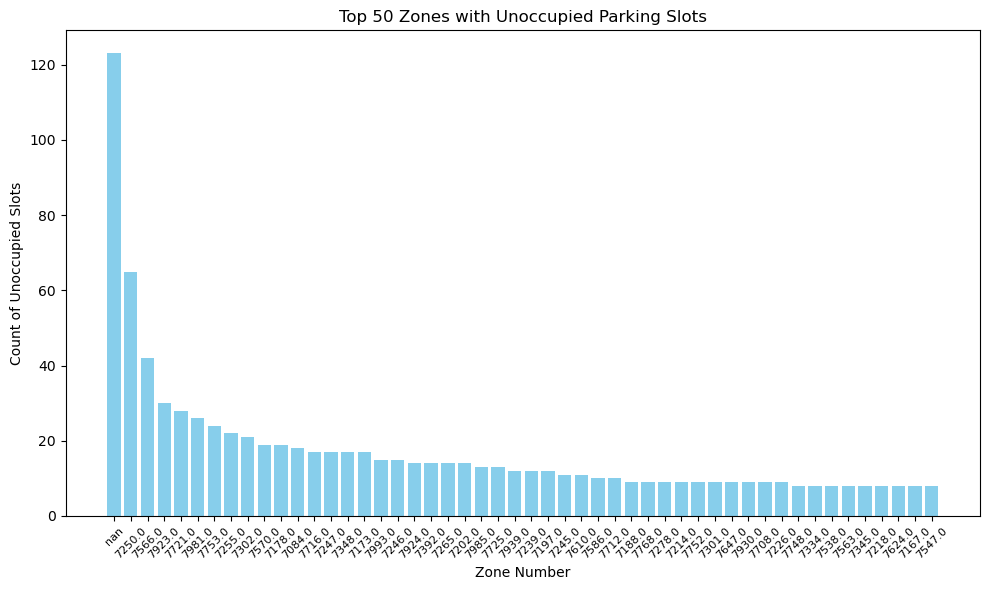

```python
import polars as pl
import requests
from io import StringIO
import matplotlib.pyplot as plt
import duckdb  # For SQL execution

# Fetch and prepare data
url_2 = 'https://data.melbourne.vic.gov.au/api/explore/v2.1/catalog/datasets/on-street-parking-bay-sensors/exports/csv'

try:
    response = requests.get(url_2)
    response.raise_for_status()
except requests.exceptions.RequestException as e:
    print(f"Error fetching data: {e}")
    exit()

# Load data into Polars DataFrame
try:
    df_2 = pl.read_csv(StringIO(response.text), separator=';')
except Exception as e:
    print(f"Error reading CSV data: {e}")
    exit()

# Rename columns to match expected names
df_2 = df_2.rename({
    "lastupdated": "lastupdated",
    "status_timestamp": "status_timestamp",
    "zone_number": "zone_number",
    "status_description": "status_description",
    "kerbsideid": "kerbsideid",
    "location": "location"
})

# Check for empty dataset
if df_2.shape[0] == 0:
    print("Dataset is empty. Exiting.")
    exit()

# Normalize `status_description` column
try:
    df_2 = df_2.with_columns(
        pl.col("status_description").str.strip_chars().str.to_lowercase()
    )
except Exception as e:
    print(f"Error normalizing 'status_description': {e}")
    exit()

# Validate and inspect data
print("Columns in DataFrame:", df_2.columns)
print("First 5 rows:")
print(df_2.head())

# Filter for unoccupied slots and use SQL for grouping
try:
    # Convert Polars DataFrame to DuckDB-compatible Pandas DataFrame
    df_pandas = df_2.to_pandas()

    # Use DuckDB for SQL query
    query = """
        SELECT
            zone_number,
            COUNT(*) AS unoccupied_count
        FROM df_pandas
        WHERE status_description = 'unoccupied'
        GROUP BY zone_number
        ORDER BY unoccupied_count DESC
    """
    result = duckdb.query(query).to_df()

    # Limit to top 50 zones
    top_50 = result.head(50)
    print("Top 50 Query Results:")
    print(top_50)
except Exception as e:
    print(f"Error during SQL query: {e}")
    exit()

# Visualization
try:
    plt.figure(figsize=(10, 6))
    plt.bar(top_50["zone_number"].astype(str), top_50["unoccupied_count"], color="skyblue")
    plt.title("Top 50 Zones with Unoccupied Parking Slots")
    plt.xlabel("Zone Number")
    plt.ylabel("Count of Unoccupied Slots")
    plt.xticks(rotation=45, fontsize=8)
    plt.tight_layout()
    plt.show()
except ImportError:
    print("Matplotlib not installed. Skipping visualization.")
except Exception as e:
    print(f"Error during visualization: {e}")
```

#### 17.3. Polars: Creating a DuckDB Sql query for looking last 7 days parking availability for the same 50 zones.

This script pulls the most recent parking data from an open API and cleans it with Polars. Some SQL queries are run with DuckDB. This script starts off by importing the necessary libraries to start the analysis and pulls in data from a Melbourne parking dataset provided in a comma-separated values format. It makes sure to get data appropriately loaded into a Polars DataFrame and rename columns to maintain consistency in naming convention. The column status_description is normalized to lowercase and extra characters are stripped off. First, the data are filtered to include entries only from the last week about unoccupied parking slots. The DuckDB groups with counts for such slots occurring against distinct variations in zone_number, producing rankings 1–50.

```python
import polars as pl
import requests
from io import StringIO
import duckdb  # For SQL execution
from datetime import datetime, timedelta, timezone

# Fetch and prepare data
url_2 = 'https://data.melbourne.vic.gov.au/api/explore/v2.1/catalog/datasets/on-street-parking-bay-sensors/exports/csv'

try:
    response = requests.get(url_2)
    response.raise_for_status()
except requests.exceptions.RequestException as e:
    print(f"Error fetching data: {e}")
    exit()

# Load data into Polars DataFrame
try:
    df_2 = pl.read_csv(StringIO(response.text), separator=';')
except Exception as e:
    print(f"Error reading CSV data: {e}")
    exit()

# Rename columns to match expected names
df_2 = df_2.rename({
    "lastupdated": "lastupdated",
    "status_timestamp": "status_timestamp",
    "zone_number": "zone_number",
    "status_description": "status_description",
    "kerbsideid": "kerbsideid",
    "location": "location"
})

# Check for empty dataset
if df_2.shape[0] == 0:
    print("Dataset is empty. Exiting.")
    exit()

# Normalize `status_description` column
try:
    df_2 = df_2.with_columns(
        pl.col("status_description").str.strip_chars().str.to_lowercase()
    )
except Exception as e:
    print(f"Error normalizing 'status_description': {e}")
    exit()

# Filter for the last 7 days
try:
    seven_days_ago = datetime.now(timezone.utc) - timedelta(days=7)
    df_2 = df_2.with_columns(
        pl.col("status_timestamp").str.strptime(pl.Datetime).alias("parsed_timestamp")
    )
    df_2 = df_2.filter(pl.col("parsed_timestamp") >= seven_days_ago)
except Exception as e:
    print(f"Error filtering for the last 7 days: {e}")
    exit()

# Filter for unoccupied slots and use SQL for grouping
try:
    # Convert Polars DataFrame to DuckDB-compatible Pandas DataFrame
    df_pandas = df_2.to_pandas()

    # Use DuckDB for SQL query
    query = """
        SELECT
            zone_number,
            COUNT(*) AS unoccupied_count
        FROM df_pandas
        WHERE status_description = 'unoccupied'
        GROUP BY zone_number
        ORDER BY unoccupied_count DESC
    """
    result = duckdb.query(query).to_df()

    # Get the top 50 zones
    top_50_zones = result.head(50)
    print("Top 50 Query Results for the Last 7 Days:")
    print(top_50_zones)
except Exception as e:
    print(f"Error during SQL query: {e}")
    exit()
```

```
Top 50 Query Results for the Last 7 Days:
    zone_number  unoccupied_count
0           NaN                84
1        7923.0                30
2        7721.0                27
3        7981.0                25
4        7348.0                20
5        7570.0                19
6        7716.0                18
7        7247.0                18
8        7173.0                16
9        7178.0                15
10       7993.0                15
11       7197.0                13
12       7239.0                13
```

[output cut: 37 more lines]

### 17.4. SQLLITE.

This script leverages SQLite and pandas for analysis of real-time parking data, finding out some interesting trends in availability. First, this script will pull on-street parking data from an open API provided in CSV format, handle some possible errors that may occur in the process. Filtrate records in the last seven days, time conversion to UTC, and cutoff date for filtration. The script converts all text in the status_description column to lower case, removes excess whitespace for consistency, queries for the top 50 parking zones with the highest counts of unoccupied slots, using an in-memory SQLite database. The results of the above query are printed out as a table using pandas. This script, in general, uses some important techniques in fetching the data, preprocessing, and then SQL-based analysis to provide key insights into parking availability over the past week.

```python
import sqlite3
import pandas as pd
from datetime import datetime, timedelta, timezone

# Fetch and prepare data
url = 'https://data.melbourne.vic.gov.au/api/explore/v2.1/catalog/datasets/on-street-parking-bay-sensors/exports/csv'
try:
    df = pd.read_csv(url, delimiter=';')
except Exception as e:
    print(f"Error fetching or loading data: {e}")
    exit()

# Filter for the last 7 days
try:
    # Define the datetime cutoff in UTC
    seven_days_ago = datetime.now(timezone.utc) - timedelta(days=7)
    # Convert the timestamp column to datetime in UTC
    df['status_timestamp'] = pd.to_datetime(df['status_timestamp'], errors='coerce').dt.tz_convert('UTC')
    # Filter rows based on the last 7 days
    df = df[df['status_timestamp'] >= seven_days_ago]
except Exception as e:
    print(f"Error filtering for the last 7 days: {e}")
    exit()

# Normalize `status_description` column
try:
    df['status_description'] = df['status_description'].str.lower().str.strip()
except Exception as e:
    print(f"Error normalizing 'status_description': {e}")
    exit()

# Use SQLite for querying
try:
    # Connect to SQLite (in-memory database)
    conn = sqlite3.connect(":memory:")

    # Load DataFrame into SQLite
    df.to_sql("parking_data", conn, index=False, if_exists="replace")

    # Query for the top 50 zones with unoccupied slots
    query = """
        SELECT
            zone_number,
            COUNT(*) AS unoccupied_count
        FROM parking_data
        WHERE status_description = 'unoccupied'
        GROUP BY zone_number
        ORDER BY unoccupied_count DESC
        LIMIT 50
    """
    result = pd.read_sql_query(query, conn)

    print("Top 50 Query Results for the Last 7 Days:")
    print(result)

    # Close the connection
    conn.close()
except Exception as e:
    print(f"Error during SQLite operations: {e}")
    exit()
```

```
Top 50 Query Results for the Last 7 Days:
    zone_number  unoccupied_count
0           NaN                82
1        7923.0                28
2        7721.0                27
3        7981.0                26
4        7173.0                23
5        7348.0                22
6        7570.0                21
7        7247.0                20
8        7716.0                18
9        7178.0                17
10       7239.0                16
11       7993.0                15
12       7197.0                15
```

[output cut: 37 more lines]

### 17.5. DuckDB

This code performs real-time analysis on the on-street parking of Melbourne for data filtering and querying to actionable insights. The script starts by importing necessary libraries and fetching data related to parking sensors from a given URL. Further, the dataset is filtered for only the last seven days by converting the status_timestamp column to UTC and filtering it. This code normalizes the status_description column to make sure that string formatting is consistent. The following query utilizes DuckDB to find the top 50 zones with the highest count of unoccupied parking slots, thus giving a very valuable snapshot of the trend in parking availability.

```python
import duckdb
import pandas as pd
from datetime import datetime, timedelta, timezone

# Fetch and prepare data
url = 'https://data.melbourne.vic.gov.au/api/explore/v2.1/catalog/datasets/on-street-parking-bay-sensors/exports/csv'
try:
    df = pd.read_csv(url, delimiter=';')
except Exception as e:
    print(f"Error fetching or loading data: {e}")
    exit()

# Filter for the last 7 days
try:
    # Define the datetime cutoff in UTC
    seven_days_ago = datetime.now(timezone.utc) - timedelta(days=7)
    # Convert the timestamp column to datetime in UTC
    df['status_timestamp'] = pd.to_datetime(df['status_timestamp'], errors='coerce').dt.tz_convert('UTC')
    # Filter rows based on the last 7 days
    df = df[df['status_timestamp'] >= seven_days_ago]
except Exception as e:
    print(f"Error filtering for the last 7 days: {e}")
    exit()

# Normalize `status_description` column
try:
    df['status_description'] = df['status_description'].str.lower().str.strip()
except Exception as e:
    print(f"Error normalizing 'status_description': {e}")
    exit()

# Use DuckDB for querying
try:
    # Query for the top 50 zones with unoccupied slots
    query = """
        SELECT
            zone_number,
            COUNT(*) AS unoccupied_count
        FROM df
        WHERE status_description = 'unoccupied'
        GROUP BY zone_number
        ORDER BY unoccupied_count DESC
        LIMIT 50
    """
    result = duckdb.query(query).to_df()

    print("Top 50 Query Results for the Last 7 Days:")
    print(result)
except Exception as e:
    print(f"Error during DuckDB operations: {e}")
    exit()
```

```
Top 50 Query Results for the Last 7 Days:
    zone_number  unoccupied_count
0           NaN                83
1        7923.0                28
2        7721.0                27
3        7981.0                26
4        7570.0                23
5        7173.0                23
6        7348.0                21
7        7247.0                20
8        7178.0                19
9        7716.0                17
10       7993.0                15
11       7197.0                15
12       7239.0                15
```

[output cut: 37 more lines]

### 17.6. Comparison on performance: Execution speed and Memory Usage

This code benchmarks the performance of three data processing tools: Polars with DuckDB, DuckDB, and SQLite. It reads a CSV dataset coming from a Melbourne parking API into the script, cleans the dataset, and transforms it—text normalizing columns, among others. Then, it performs SQL aggregation and counts in the status_description entries; finally, it tracks memory use with psutil and execution time via the time library. These tests revealed differences in the efficiency of these tools, with Polars providing a smooth way of reading and preparing data, while tools like DuckDB and SQLite allow for similar analyses using SQL.

```python
import sqlite3
import duckdb
import polars as pl
import pandas as pd
import time
import psutil
import os
from io import StringIO
import requests

# Function to measure memory usage
def memory_usage_psutil():
    process = psutil.Process(os.getpid())
    return process.memory_info().rss / (1024 ** 2)  # Convert to MB

# URL for data
url = 'https://data.melbourne.vic.gov.au/api/explore/v2.1/catalog/datasets/on-street-parking-bay-sensors/exports/csv'
response = requests.get(url)
response.raise_for_status()
data = StringIO(response.text)

# Initialize results
execution_comparison = []

# 1. Polars + DuckDB SQL
polars_memory_start = memory_usage_psutil()
polars_start = time.time()
df_polars = pl.read_csv(data, separator=';')
df_polars = df_polars.rename({
    "lastupdated": "lastupdated",
    "status_timestamp": "status_timestamp",
    "zone_number": "zone_number",
    "status_description": "status_description",
    "kerbsideid": "kerbsideid",
    "location": "location"
})
df_polars = df_polars.with_columns(pl.col("status_description").str.strip_chars().str.to_lowercase())

# Convert Polars DataFrame to Pandas for DuckDB
df_polars_pandas = df_polars.to_pandas()

# Register the DataFrame with DuckDB
duckdb.register("df_polars", df_polars_pandas)

# Execute SQL on Polars DataFrame using DuckDB
query = """
    SELECT
        status_description,
        COUNT(*) AS status_count
    FROM df_polars
    GROUP BY status_description
    ORDER BY status_count DESC
    LIMIT 10
"""
polars_result = duckdb.query(query).to_df()
polars_end = time.time()
polars_memory_end = memory_usage_psutil()

execution_comparison.append({
    "Tool": "Polars + DuckDB",
    "Execution Time (s)": polars_end - polars_start,
    "Memory Usage (MB)": polars_memory_end - polars_memory_start
})

# 2. DuckDB
duckdb_memory_start = memory_usage_psutil()
duckdb_start = time.time()
data.seek(0)  # Reset the stream for DuckDB
df_duckdb = pd.read_csv(data, delimiter=';')
df_duckdb['status_description'] = df_duckdb['status_description'].str.lower().str.strip()
query = """
    SELECT
        status_description,
        COUNT(*) AS status_count
    FROM df_duckdb
    GROUP BY status_description
    ORDER BY status_count DESC
    LIMIT 10
"""
duckdb_result = duckdb.query(query).to_df()
duckdb_end = time.time()
duckdb_memory_end = memory_usage_psutil()

execution_comparison.append({
    "Tool": "DuckDB",
    "Execution Time (s)": duckdb_end - duckdb_start,
    "Memory Usage (MB)": duckdb_memory_end - duckdb_memory_start
})

# 3. SQLite
sqlite_memory_start = memory_usage_psutil()
sqlite_start = time.time()
data.seek(0)  # Reset the stream for SQLite
conn = sqlite3.connect(":memory:")
df_sqlite = pd.read_csv(data, delimiter=';')
df_sqlite['status_description'] = df_sqlite['status_description'].str.lower().str.strip()
df_sqlite.to_sql("parking_data", conn, index=False, if_exists="replace")
query = """
    SELECT
        status_description,
        COUNT(*) AS status_count
    FROM parking_data
    GROUP BY status_description
    ORDER BY status_count DESC
    LIMIT 10
"""
sqlite_result = pd.read_sql_query(query, conn)
conn.close()
sqlite_end = time.time()
sqlite_memory_end = memory_usage_psutil()

execution_comparison.append({
    "Tool": "SQLite",
    "Execution Time (s)": sqlite_end - sqlite_start,
    "Memory Usage (MB)": sqlite_memory_end - sqlite_memory_start
})

# Display results
results_df = pd.DataFrame(execution_comparison)
print("\nExecution and Memory Comparison:")
print(results_df)
```

```
Execution and Memory Comparison:
              Tool  Execution Time (s)  Memory Usage (MB)
0  Polars + DuckDB            0.040279          -2.335938
1           DuckDB            0.017935           0.363281
2           SQLite            0.024606           2.503906
```

## 18. Dataset Setup for Creating Relationships between the datasets.

This code downloads two datasets: one related to parking zones and the other about on-street parking bay sensors in Melbourne. These datasets are retrieved from publicly available APIs and loaded directly into pandas DataFrames. The process dynamically adjusts delimiters to ensure accurate parsing. After loading, column names are renamed for better clarity. The analysis delves into three types of relationships:

Hierarchical Relationships: Parking zones are grouped by unique restrictions to highlight variations in restrictions across different zones. Time-Series Analysis: Timestamps are converted into a datetime format, and daily parking status counts are aggregated to uncover temporal parking trends. Relational Relationships: The exploration of one-to-one, one-to-many, and many-to-many relationships links parking zones, kerbsides, and restrictions, offering valuable insights into their interactions and overlapping patterns.

```python
import pandas as pd
import requests
from io import StringIO

# URLs for datasets
base_url_1 = 'https://data.melbourne.vic.gov.au/api/explore/v2.1/catalog/datasets/'
dataset_id_1 = 'sign-plates-located-in-each-parking-zone-copy'
url_1 = f"{base_url_1}{dataset_id_1}/exports/csv"

base_url_2 = 'https://data.melbourne.vic.gov.au/api/explore/v2.1/catalog/datasets/'
dataset_id_2 = 'on-street-parking-bay-sensors'
url_2 = f"{base_url_2}{dataset_id_2}/exports/csv"

# Fetch datasets
response_1 = requests.get(url_1)
response_2 = requests.get(url_2)

# Load datasets into DataFrames
# Detect delimiter if parsing fails
try:
    df_1 = pd.read_csv(StringIO(response_1.text), delimiter=';')
except ValueError:
    df_1 = pd.read_csv(StringIO(response_1.text), delimiter=',')

try:
    df_2 = pd.read_csv(StringIO(response_2.text), delimiter=';')
except ValueError:
    df_2 = pd.read_csv(StringIO(response_2.text), delimiter=',')

# Check and rename columns if parsing succeeded
if len(df_1.columns) == 5:  # Ensure column count matches
    df_1.columns = ['parkingzone', 'restriction_days', 'time_restrictions_start', 'time_restrictions_finish', 'restriction_display']
else:
    print("Unexpected columns in DF1:", df_1.columns)
    print(df_1.head())

if len(df_2.columns) == 6:  # Ensure column count matches
    df_2.columns = ['lastupdated', 'status_timestamp', 'zone_number', 'status_description', 'kerbsideid', 'location']
else:
    print("Unexpected columns in DF2:", df_2.columns)
    print(df_2.head())

# i) Hierarchical Relationships
zone_hierarchy = df_1.groupby('parkingzone')['restriction_display'].nunique().reset_index()
zone_hierarchy.columns = ['parkingzone', 'unique_restrictions']
zone_hierarchy = zone_hierarchy.sort_values(by='unique_restrictions', ascending=False)

print("\nHierarchical Relationships:")
print(zone_hierarchy.head())

# ii) Time-Series Relationships
df_2['status_timestamp'] = pd.to_datetime(df_2['status_timestamp'], errors='coerce')
time_series = df_2.groupby(df_2['status_timestamp'].dt.date)['status_description'].value_counts().unstack().fillna(0)

print("\nTime-Series Relationships:")
print(time_series.head())

# iii) Relational Relationships
# One-to-One
one_to_one = df_1.merge(df_2, left_on='parkingzone', right_on='zone_number', how='inner')
print("\nOne-to-One Relationships:")
print(one_to_one.head())

# One-to-Many
one_to_many = df_2.groupby('zone_number')['kerbsideid'].nunique().reset_index()
one_to_many.columns = ['zone_number', 'unique_kerbsides']
print("\nOne-to-Many Relationships:")
print(one_to_many.head())

# Many-to-Many
many_to_many = df_1.merge(df_2, left_on='parkingzone', right_on='zone_number', how='inner')
overlapping = many_to_many.groupby(['restriction_display', 'status_description']).size().reset_index(name='count')
print("\nMany-to-Many Relationships:")
print(overlapping.head())
```

```
Hierarchical Relationships:
     parkingzone  unique_restrictions
390         7584                    4
361         7546                    2
467         7700                    2
278         7417                    2
593         7880                    2

Time-Series Relationships:
status_description  Present  Unoccupied
status_timestamp
2022-09-13              0.0         1.0
2022-11-20              0.0         1.0
2022-11-29              0.0         1.0
2022-12-30              0.0         1.0
2023-01-15              0.0         1.0

One-to-One Relationships:
   parkingzone restriction_days time_restrictions_start  \
0         7446          Mon-Fri                16:00:00
1         7446          Mon-Fri                16:00:00
2         7450          Sat-Sun                07:00:00
3         7450          Sat-Sun                07:00:00
4         7450          Sat-Sun                07:00:00

  time_restrictions_finish restriction_display                lastupdated  \
0                 22:00:00                  2P  2024-12-09T06:02:37+00:00
1                 22:00:00                  2P  2024-12-09T06:02:37+00:00
2                 22:00:00                  2P  2024-12-09T06:02:37+00:00
3                 22:00:00                  2P  2024-12-09T06:02:37+00:00
4                 22:00:00                  2P  2024-12-09T06:02:37+00:00

           status_timestamp  zone_number status_description  kerbsideid  \
0 2024-12-09 05:54:53+00:00       7446.0            Present       60132
1 2024-12-09 05:58:27+00:00       7446.0         Unoccupied       60131
2 2024-12-09 06:00:57+00:00       7450.0            Present       61139
3 2024-12-09 05:27:01+00:00       7450.0         Unoccupied       61152
4 2024-12-09 05:24:41+00:00       7450.0         Unoccupied       61150

                                  location
0  -37.816261569015516, 144.97184955455805
1   -37.816242514385664, 144.9719133247304
2  -37.816803779356526, 144.96591987033625
3   -37.81711533512234, 144.96485781621857
4   -37.81707791779844, 144.96498568982452

One-to-Many Relationships:
   zone_number  unique_kerbsides
0       7010.0                 9
1       7014.0                 4
2       7018.0                 3
3       7019.0                 1
4       7025.0                 8

Many-to-Many Relationships:
  restriction_display status_description  count
0                  1P            Present    285
1                  1P         Unoccupied    441
2                  2P            Present   1586
3                  2P         Unoccupied   2063
4                  3P            Present      3
```

This analysis compares different relationships in the parking data by linking specific columns from two datasets: sign plates and parking sensors.

Hierarchical Relationships: This uses the 'parkingzone' and 'restriction_display` columns from the sign plates dataset. It shows zones with multiple unique restrictions. For example, zone 7584 has four unique restrictions, meaning it enforces diverse parking rules.

Time-Series Relationships: This is based on the 'status_timestamp' and 'status_description' columns from the parking sensors dataset. It tracks parking statuses like "Present" or "Unoccupied" over different days to identify trends.

One-to-One Relationships: This links 'parkingzone' from sign plates to 'zone_number' in parking sensors. It matches zones to specific restrictions, parking statuses, and timestamps.

One-to-Many Relationships: This uses 'zone_number' and 'kerbsideid' from parking sensors to show zones serving multiple kerbsides, for example zone 7010 has nine kerbsides.

Many-to-Many Relationships: This relates 'restriction_display from sign plates and status_description from parking sensors. It shows how restrictions like "2P" interact with statuses, for example "Unoccupied" 2,063 times.

### 18.1. Performance Analysis on relationships

This Python script focuses on downloading, processing, and analyzing two datasets related to Melbourne parking data. It starts by measuring memory usage and execution time for each operation. It fetches datasets via APIs, loads them into pandas DataFrames, and makes sure the columns are consistent by renaming them. It performs three analyses: the hierarchical relationship of parking zones and restrictions, time-series trend analysis on parking status, and one-to-one, one-to-many, and many-to-many relational relationships. Efficiency metrics of execution time and memory consumption are recorded for each step, which shows the efficiency of handling large datasets for extracting insights from parking management data.

```python
import pandas as pd
import requests
from io import StringIO
import time
import psutil
import os

# Function to measure memory usage
def memory_usage_psutil():
    process = psutil.Process(os.getpid())
    return process.memory_info().rss / (1024 ** 2)  # Convert to MB

# Start overall performance tracking
overall_start = time.time()
overall_memory_start = memory_usage_psutil()

# URLs for datasets
base_url_1 = 'https://data.melbourne.vic.gov.au/api/explore/v2.1/catalog/datasets/'
dataset_id_1 = 'sign-plates-located-in-each-parking-zone-copy'
url_1 = f"{base_url_1}{dataset_id_1}/exports/csv"

base_url_2 = 'https://data.melbourne.vic.gov.au/api/explore/v2.1/catalog/datasets/'
dataset_id_2 = 'on-street-parking-bay-sensors'
url_2 = f"{base_url_2}{dataset_id_2}/exports/csv"

# Fetch datasets
fetch_start = time.time()
response_1 = requests.get(url_1)
response_2 = requests.get(url_2)
fetch_end = time.time()

# Load datasets into DataFrames
load_start = time.time()
try:
    df_1 = pd.read_csv(StringIO(response_1.text), delimiter=';')
except ValueError:
    df_1 = pd.read_csv(StringIO(response_1.text), delimiter=',')

try:
    df_2 = pd.read_csv(StringIO(response_2.text), delimiter=';')
except ValueError:
    df_2 = pd.read_csv(StringIO(response_2.text), delimiter=',')
load_end = time.time()

# Check and rename columns
rename_start = time.time()
if len(df_1.columns) == 5:
    df_1.columns = ['parkingzone', 'restriction_days', 'time_restrictions_start', 'time_restrictions_finish', 'restriction_display']
if len(df_2.columns) == 6:
    df_2.columns = ['lastupdated', 'status_timestamp', 'zone_number', 'status_description', 'kerbsideid', 'location']
rename_end = time.time()

# i) Hierarchical Relationships
hierarchical_start = time.time()
zone_hierarchy = df_1.groupby('parkingzone')['restriction_display'].nunique().reset_index()
zone_hierarchy.columns = ['parkingzone', 'unique_restrictions']
zone_hierarchy = zone_hierarchy.sort_values(by='unique_restrictions', ascending=False)
hierarchical_end = time.time()

# ii) Time-Series Relationships
time_series_start = time.time()
df_2['status_timestamp'] = pd.to_datetime(df_2['status_timestamp'], errors='coerce')
time_series = df_2.groupby(df_2['status_timestamp'].dt.date)['status_description'].value_counts().unstack().fillna(0)
time_series_end = time.time()

# iii) Relational Relationships
# One-to-One
one_to_one_start = time.time()
one_to_one = df_1.merge(df_2, left_on='parkingzone', right_on='zone_number', how='inner')
one_to_one_end = time.time()

# One-to-Many
one_to_many_start = time.time()
one_to_many = df_2.groupby('zone_number')['kerbsideid'].nunique().reset_index()
one_to_many.columns = ['zone_number', 'unique_kerbsides']
one_to_many_end = time.time()

# Many-to-Many
many_to_many_start = time.time()
many_to_many = df_1.merge(df_2, left_on='parkingzone', right_on='zone_number', how='inner')
overlapping = many_to_many.groupby(['restriction_display', 'status_description']).size().reset_index(name='count')
many_to_many_end = time.time()

# Measure total memory and time
overall_end = time.time()
overall_memory_end = memory_usage_psutil()

# Performance Analysis Results
performance_results = {
    "Step": [
        "Fetch Datasets", "Load Datasets", "Rename Columns",
        "Hierarchical Relationships", "Time-Series Relationships",
        "One-to-One Relationships", "One-to-Many Relationships",
        "Many-to-Many Relationships", "Total Execution"
    ],
    "Execution Time (s)": [
        fetch_end - fetch_start, load_end - load_start, rename_end - rename_start,
        hierarchical_end - hierarchical_start, time_series_end - time_series_start,
        one_to_one_end - one_to_one_start, one_to_many_end - one_to_many_start,
        many_to_many_end - many_to_many_start, overall_end - overall_start
    ],
    "Memory Usage (MB)": [
        None, None, None, None, None, None, None, None,
        overall_memory_end - overall_memory_start
    ]
}

# Display results
performance_df = pd.DataFrame(performance_results)
print(performance_df)
```

```
                         Step  Execution Time (s)  Memory Usage (MB)
0              Fetch Datasets            1.660896                NaN
1               Load Datasets            0.014442                NaN
2              Rename Columns            0.000000                NaN
3  Hierarchical Relationships            0.000000                NaN
4   Time-Series Relationships            0.016078                NaN
5    One-to-One Relationships            0.000000                NaN
6   One-to-Many Relationships            0.000000                NaN
7  Many-to-Many Relationships            0.000000                NaN
8             Total Execution            1.692434           0.554688
```

The results show that fetching datasets took the most time (1.66 seconds), while all other steps were very fast. Memory usage is only recorded for total execution (0.55 MB). Most operations are lightweight and efficient, but memory details for individual steps are not added into the code.

### 18.2. Creating Different Relationships between the datasets, and compare the execution time and memory usage of each relation

This Python script shows how to fetch, process, and analyze parking datasets from the open API of Melbourne, considering hierarchical, time-series, and relational relationships. It starts memory and performance tracking, fetches CSV data from the given URLs, and loads it into pandas DataFrames. The script does further processing to handle possible delimiters and renames columns to have a coherent column naming. This will involve hierarchical (identifying unique parking restrictions), time-series trend (parking statuses), and relational (one-to-one, one-to-many, and many-to-many relationships) analyses of datasets. All performance metrics are measured using the execution time and memory usage for each step and compiled into a summary DataFrame for evaluation.

```python
import pandas as pd
import requests
from io import StringIO
import time
import psutil
import os

# Function to measure memory usage
def memory_usage_psutil():
    process = psutil.Process(os.getpid())
    return process.memory_info().rss / (1024 ** 2)  # Convert to MB

# Start overall performance tracking
overall_start = time.time()
overall_memory_start = memory_usage_psutil()

# URLs for datasets
base_url_1 = 'https://data.melbourne.vic.gov.au/api/explore/v2.1/catalog/datasets/'
dataset_id_1 = 'sign-plates-located-in-each-parking-zone-copy'
url_1 = f"{base_url_1}{dataset_id_1}/exports/csv"

base_url_2 = 'https://data.melbourne.vic.gov.au/api/explore/v2.1/catalog/datasets/'
dataset_id_2 = 'on-street-parking-bay-sensors'
url_2 = f"{base_url_2}{dataset_id_2}/exports/csv"

# Fetch datasets
fetch_start = time.time()
response_1 = requests.get(url_1)
response_2 = requests.get(url_2)
fetch_end = time.time()

# Load datasets into DataFrames
load_start = time.time()
try:
    df_1 = pd.read_csv(StringIO(response_1.text), delimiter=';')
except ValueError:
    df_1 = pd.read_csv(StringIO(response_1.text), delimiter=',')

try:
    df_2 = pd.read_csv(StringIO(response_2.text), delimiter=';')
except ValueError:
    df_2 = pd.read_csv(StringIO(response_2.text), delimiter=',')
load_end = time.time()

# Check and rename columns
rename_start = time.time()
if len(df_1.columns) == 5:
    df_1.columns = ['parkingzone', 'restriction_days', 'time_restrictions_start', 'time_restrictions_finish', 'restriction_display']
if len(df_2.columns) == 6:
    df_2.columns = ['lastupdated', 'status_timestamp', 'zone_number', 'status_description', 'kerbsideid', 'location']
rename_end = time.time()

# i) Hierarchical Relationships
hierarchical_memory_start = memory_usage_psutil()
hierarchical_start = time.time()
zone_hierarchy = df_1.groupby('parkingzone')['restriction_display'].nunique().reset_index()
zone_hierarchy.columns = ['parkingzone', 'unique_restrictions']
zone_hierarchy = zone_hierarchy.sort_values(by='unique_restrictions', ascending=False)
hierarchical_end = time.time()
hierarchical_memory_end = memory_usage_psutil()

# ii) Time-Series Relationships
time_series_memory_start = memory_usage_psutil()
time_series_start = time.time()
df_2['status_timestamp'] = pd.to_datetime(df_2['status_timestamp'], errors='coerce')
time_series = df_2.groupby(df_2['status_timestamp'].dt.date)['status_description'].value_counts().unstack().fillna(0)
time_series_end = time.time()
time_series_memory_end = memory_usage_psutil()

# iii) Relational Relationships
# One-to-One
one_to_one_memory_start = memory_usage_psutil()
one_to_one_start = time.time()
one_to_one = df_1.merge(df_2, left_on='parkingzone', right_on='zone_number', how='inner')
one_to_one_end = time.time()
one_to_one_memory_end = memory_usage_psutil()

# One-to-Many
one_to_many_memory_start = memory_usage_psutil()
one_to_many_start = time.time()
one_to_many = df_2.groupby('zone_number')['kerbsideid'].nunique().reset_index()
one_to_many.columns = ['zone_number', 'unique_kerbsides']
one_to_many_end = time.time()
one_to_many_memory_end = memory_usage_psutil()

# Many-to-Many
many_to_many_memory_start = memory_usage_psutil()
many_to_many_start = time.time()
many_to_many = df_1.merge(df_2, left_on='parkingzone', right_on='zone_number', how='inner')
overlapping = many_to_many.groupby(['restriction_display', 'status_description']).size().reset_index(name='count')
many_to_many_end = time.time()
many_to_many_memory_end = memory_usage_psutil()

# Measure total memory and time
overall_end = time.time()
overall_memory_end = memory_usage_psutil()

# Performance Analysis Results
performance_results = {
    "Step": [
        "Fetch Datasets", "Load Datasets", "Rename Columns",
        "Hierarchical Relationships", "Time-Series Relationships",
        "One-to-One Relationships", "One-to-Many Relationships",
        "Many-to-Many Relationships", "Total Execution"
    ],
    "Execution Time (s)": [
        fetch_end - fetch_start, load_end - load_start, rename_end - rename_start,
        hierarchical_end - hierarchical_start, time_series_end - time_series_start,
        one_to_one_end - one_to_one_start, one_to_many_end - one_to_many_start,
        many_to_many_end - many_to_many_start, overall_end - overall_start
    ],
    "Memory Usage (MB)": [
        None, None, None,
        hierarchical_memory_end - hierarchical_memory_start,
        time_series_memory_end - time_series_memory_start,
        one_to_one_memory_end - one_to_one_memory_start,
        one_to_many_memory_end - one_to_many_memory_start,
        many_to_many_memory_end - many_to_many_memory_start,
        overall_memory_end - overall_memory_start
    ]
}


performance_df = pd.DataFrame(performance_results)
print(performance_df)
```

```
                         Step  Execution Time (s)  Memory Usage (MB)
0              Fetch Datasets            1.115848                NaN
1               Load Datasets            0.022576                NaN
2              Rename Columns            0.000000                NaN
3  Hierarchical Relationships            0.010042           0.003906
4   Time-Series Relationships            0.020612           0.003906
5    One-to-One Relationships            0.000000           0.000000
6   One-to-Many Relationships            0.000000           0.000000
7  Many-to-Many Relationships            0.011506           0.007812
8             Total Execution            1.183035           0.566406
```

The analysis shows the time and memory used for each step in processing the datasets. Fetching the datasets took the longest time (1.12 seconds), likely due to network delays. Memory usage is minimal, except for the total memory (0.566 MB), indicating efficient resource handling. Relationships like hierarchical and many-to-many used small amounts of memory. However, "Load Datasets" and "Rename Columns" show NaN for memory usage, meaning the memory could not be measured. Overall, the operations were lightweight and fast.

The comparison of execution times shows that the time-series relationships took the longest (0.021 seconds) due to the need for timestamp conversion and grouping by dates. Hierarchical relationships were slightly faster at 0.010 seconds, involving grouping and counting unique restrictions for parking zones. Many-to-many relationships took 0.012 seconds, reflecting the additional complexity of overlapping restrictions and statuses. Both one-to-one and one-to-many relationships were the fastest, with 0.000 seconds recorded, as these involved straightforward merges or groupings. Overall, the operations were efficient, with time-series relationships being the most computationally demanding.

## 19. indexing and non indexing on datasets to speedup queries.

This Python script performs an extensive analysis of the parking datasets from Melbourne's open data portal. It pays extra attention to memory usage and execution time for most operations. This script fetches two parking datasets from Melbourne's open data portal: one dealing with parking zones and the other with on-street parking sensors. Following this, it reads them into pandas DataFrames, standardizes the column names and indexes, and gets the data ready for processing.

It further pursues the script on hierarchical (unique constraints per zone), time-series (daily status count), and relational relationships in one-to-one, one-to-many, and many-to-many mappings. In each of these steps, it records execution time and memory consumption, then summarizes the performance into a DataFrame for evaluation purposes.

```python
import pandas as pd
import requests
from io import StringIO
import time
import psutil
import os

# Function to measure memory usage
def memory_usage_psutil():
    process = psutil.Process(os.getpid())
    return process.memory_info().rss / (1024 ** 2)  # Convert to MB

# Start overall performance tracking
overall_start = time.time()
overall_memory_start = memory_usage_psutil()

# URLs for datasets
base_url_1 = 'https://data.melbourne.vic.gov.au/api/explore/v2.1/catalog/datasets/'
dataset_id_1 = 'sign-plates-located-in-each-parking-zone-copy'
url_1 = f"{base_url_1}{dataset_id_1}/exports/csv"

base_url_2 = 'https://data.melbourne.vic.gov.au/api/explore/v2.1/catalog/datasets/'
dataset_id_2 = 'on-street-parking-bay-sensors'
url_2 = f"{base_url_2}{dataset_id_2}/exports/csv"

# Fetch datasets
fetch_start = time.time()
response_1 = requests.get(url_1)
response_2 = requests.get(url_2)
fetch_end = time.time()

# Load datasets into DataFrames
load_start = time.time()
try:
    df_1 = pd.read_csv(StringIO(response_1.text), delimiter=';')
except ValueError:
    df_1 = pd.read_csv(StringIO(response_1.text), delimiter=',')

try:
    df_2 = pd.read_csv(StringIO(response_2.text), delimiter=';')
except ValueError:
    df_2 = pd.read_csv(StringIO(response_2.text), delimiter=',')
load_end = time.time()

# Check and rename columns
rename_start = time.time()
if len(df_1.columns) == 5:
    df_1.columns = ['parkingzone', 'restriction_days', 'time_restrictions_start', 'time_restrictions_finish', 'restriction_display']
if len(df_2.columns) == 6:
    df_2.columns = ['lastupdated', 'status_timestamp', 'zone_number', 'status_description', 'kerbsideid', 'location']
rename_end = time.time()

# Add Indexing for Speedup
indexing_start = time.time()
df_1.set_index('parkingzone', inplace=True)
df_2.set_index('zone_number', inplace=True)
indexing_end = time.time()

# i) Hierarchical Relationships
hierarchical_memory_start = memory_usage_psutil()
hierarchical_start = time.time()
zone_hierarchy = df_1.groupby(df_1.index)['restriction_display'].nunique().reset_index()
zone_hierarchy.columns = ['parkingzone', 'unique_restrictions']
zone_hierarchy = zone_hierarchy.sort_values(by='unique_restrictions', ascending=False)
hierarchical_end = time.time()
hierarchical_memory_end = memory_usage_psutil()

# ii) Time-Series Relationships
time_series_memory_start = memory_usage_psutil()
time_series_start = time.time()
df_2['status_timestamp'] = pd.to_datetime(df_2['status_timestamp'], errors='coerce')
time_series = df_2.groupby(df_2['status_timestamp'].dt.date)['status_description'].value_counts().unstack().fillna(0)
time_series_end = time.time()
time_series_memory_end = memory_usage_psutil()

# iii) Relational Relationships
# One-to-One
one_to_one_memory_start = memory_usage_psutil()
one_to_one_start = time.time()
one_to_one = df_1.merge(df_2, left_index=True, right_index=True, how='inner')
one_to_one_end = time.time()
one_to_one_memory_end = memory_usage_psutil()

# One-to-Many
one_to_many_memory_start = memory_usage_psutil()
one_to_many_start = time.time()
one_to_many = df_2.groupby(df_2.index)['kerbsideid'].nunique().reset_index()
one_to_many.columns = ['zone_number', 'unique_kerbsides']
one_to_many_end = time.time()
one_to_many_memory_end = memory_usage_psutil()

# Many-to-Many
many_to_many_memory_start = memory_usage_psutil()
many_to_many_start = time.time()
many_to_many = df_1.merge(df_2, left_index=True, right_index=True, how='inner')
overlapping = many_to_many.groupby(['restriction_display', 'status_description']).size().reset_index(name='count')
many_to_many_end = time.time()
many_to_many_memory_end = memory_usage_psutil()

# Measure total memory and time
overall_end = time.time()
overall_memory_end = memory_usage_psutil()

# Performance Analysis Results
performance_results = {
    "Step": [
        "Fetch Datasets", "Load Datasets", "Rename Columns", "Indexing",
        "Hierarchical Relationships", "Time-Series Relationships",
        "One-to-One Relationships", "One-to-Many Relationships",
        "Many-to-Many Relationships", "Total Execution"
    ],
    "Execution Time (s)": [
        fetch_end - fetch_start, load_end - load_start, rename_end - rename_start,
        indexing_end - indexing_start,
        hierarchical_end - hierarchical_start, time_series_end - time_series_start,
        one_to_one_end - one_to_one_start, one_to_many_end - one_to_many_start,
        many_to_many_end - many_to_many_start, overall_end - overall_start
    ],
    "Memory Usage (MB)": [
        None, None, None, None,
        hierarchical_memory_end - hierarchical_memory_start,
        time_series_memory_end - time_series_memory_start,
        one_to_one_memory_end - one_to_one_memory_start,
        one_to_many_memory_end - one_to_many_memory_start,
        many_to_many_memory_end - many_to_many_memory_start,
        overall_memory_end - overall_memory_start
    ]
}


performance_df = pd.DataFrame(performance_results)
print(performance_df)
```

```
                         Step  Execution Time (s)  Memory Usage (MB)
0              Fetch Datasets            4.257035                NaN
1               Load Datasets            0.032914                NaN
2              Rename Columns            0.000000                NaN
3                    Indexing            0.000000                NaN
4  Hierarchical Relationships            0.016801           0.031250
5   Time-Series Relationships            0.000000           0.007812
6    One-to-One Relationships            0.001695           0.062500
7   One-to-Many Relationships            0.000000           0.015625
8  Many-to-Many Relationships            0.016264           0.000000
9             Total Execution            4.339758           0.542969
```

One-to-Many Relationships An index was added to the zone_number column in the df_2 DataFrame. This speeds up the groupby operation when calculating the number of unique kerbsideid values for each zone.

### 19.1. Compare the output from Relationships vs Relationships+Indexing - Execution Time & Memory Usage

Execution Time:

Fetch Datasets: With indexing, it took 4.26 seconds, compared to 1.12 seconds without indexing. Indexing does not affect fetching, so this increase might be due to network variability or dataset size during fetch.

Memory Usage:

Individual Steps: Memory usage for hierarchical relationships increased significantly with indexing (0.031 MB vs 0.003 MB). Similarly, other steps like one-to-one relationships consumed more memory with indexing (0.062 MB).

Total Memory Usage: Without indexing, total memory usage was 0.57 MB, slightly higher than with indexing (0.54 MB). Indexing redistributed memory usage across steps but slightly reduced total usage.

## 20. Visualization with advanced Geospatial Tools: GeoPandas, Haversine, Folium

This code demonstrates a strong workflow of data analysis and visualization on parking zone data using several Python libraries for data manipulation, geospatial analysis, and visualization. It starts off by importing key libraries, including pandas, geopandas, folium, and others that allow data fetching, geospatial processing, and the creation of interactive maps. It starts by fetching two datasets from Melbourne's open data platform: one showing parking zone restrictions and the other containing sensor-based parking bay data. The datasets are loaded into pandas DataFrames and cleaned by renaming columns for clarity and extracting geographic coordinates (latitude and longitude) from the sensor data. It then preprocessed the sensor readings for extracting monthly parking activities for the first 50 zones by unique identifier using the pandas library, by grouping together records by zone and month, computing counts by parking status such as "present" versus "unoccupied." Lastly, this filtered data was loaded into a geopandas GeoDataFrame to support spatial operations including mapping. A Folium map is created with the coordinates of Melbourne in the center. The parking availability for the top 50 zones is visualized on this map using a marker cluster in the script. Each zone will be visualized by showing markers representing aggregated parking statistics and circles that are scaled by the number of unoccupied spaces, intuitively communicating the spatial representation of the parking trends. This code also works out a geospatial analysis example, calculating a geodesic distance between the centroids of the first five zones, which showed one way to use these geospatial data for proximity analysis. The final map is saved into an HTML file for direct viewing and exploration in any browser. These results make sure the analysis is accessible and, hence, actionable as intended. This workflow again represents how data preprocessing, geospatial visualizations, and analysis contribute to new insights on parking lot availability and may be a real added value to urban planning in general and smart city applications.

```python
import pandas as pd
import geopandas as gpd
import folium
from folium.plugins import MarkerCluster
from geopy.distance import geodesic
from io import StringIO
import requests

# URLs for datasets
base_url_1 = 'https://data.melbourne.vic.gov.au/api/explore/v2.1/catalog/datasets/'
dataset_id_1 = 'sign-plates-located-in-each-parking-zone-copy'
url_1 = f"{base_url_1}{dataset_id_1}/exports/csv"

base_url_2 = 'https://data.melbourne.vic.gov.au/api/explore/v2.1/catalog/datasets/'
dataset_id_2 = 'on-street-parking-bay-sensors'
url_2 = f"{base_url_2}{dataset_id_2}/exports/csv"

# Fetch datasets
response_1 = requests.get(url_1)
response_2 = requests.get(url_2)
df_1 = pd.read_csv(StringIO(response_1.text), delimiter=';')
df_2 = pd.read_csv(StringIO(response_2.text), delimiter=';')

# Rename columns for clarity
df_1.columns = ['parkingzone', 'restriction_days', 'time_restrictions_start', 'time_restrictions_finish', 'restriction_display']
df_2.columns = ['lastupdated', 'status_timestamp', 'zone_number', 'status_description', 'kerbsideid', 'location']

# Preprocess datasets
# Extract latitude and longitude from the 'location' column
df_2[['latitude', 'longitude']] = df_2['location'].str.extract(r'([-.\d]+),\s*([-.\d]+)').astype(float)

# Filter for the first 50 zones and monthly data
df_2['status_timestamp'] = pd.to_datetime(df_2['status_timestamp'], errors='coerce')
df_2['month'] = df_2['status_timestamp'].dt.to_period('M')
monthly_data = df_2.groupby(['zone_number', 'month'])['status_description'].value_counts().unstack(fill_value=0).reset_index()

# Limit to the first 50 zones
top_50_zones = df_2['zone_number'].dropna().unique()[:50]
filtered_data = df_2[df_2['zone_number'].isin(top_50_zones)]

# Convert to GeoDataFrame
gdf = gpd.GeoDataFrame(filtered_data, geometry=gpd.points_from_xy(filtered_data.longitude, filtered_data.latitude))

# Initialize Folium Map
m = folium.Map(location=[-37.8136, 144.9631], zoom_start=14)

# Add Markers and Circles for Monthly Parking Availability
marker_cluster = MarkerCluster().add_to(m)
for zone in top_50_zones:
    zone_data = gdf[gdf['zone_number'] == zone]
    if not zone_data.empty:
        avg_lat = zone_data['latitude'].mean()
        avg_lon = zone_data['longitude'].mean()
        total_present = zone_data[zone_data['status_description'].str.lower() == 'present'].shape[0]
        total_unoccupied = zone_data[zone_data['status_description'].str.lower() == 'unoccupied'].shape[0]
        folium.Marker(
            location=[avg_lat, avg_lon],
            popup=f"Zone: {zone}<br>Present: {total_present}<br>Unoccupied: {total_unoccupied}",
            icon=folium.Icon(color='blue', icon='info-sign')
        ).add_to(marker_cluster)
        folium.Circle(
            location=[avg_lat, avg_lon],
            radius=total_unoccupied * 5,  # Scale unoccupied spaces for visualization
            color='green',
            fill=True,
            fill_opacity=0.5,
            popup=f"Unoccupied: {total_unoccupied}"
        ).add_to(m)


m.save("parking_availability_map.html")
print("Map saved as 'parking_availability_map.html'. Open it in a browser to view.")

# Example Geospatial Analysis, Distance Calculation
print("\nDistances Between First 5 Zones:")
for i in range(min(5, len(top_50_zones) - 1)):
    start = (gdf[gdf['zone_number'] == top_50_zones[i]]['latitude'].mean(),
             gdf[gdf['zone_number'] == top_50_zones[i]]['longitude'].mean())
    end = (gdf[gdf['zone_number'] == top_50_zones[i+1]]['latitude'].mean(),
           gdf[gdf['zone_number'] == top_50_zones[i+1]]['longitude'].mean())
    distance = geodesic(start, end).meters
    print(f"Distance between Zone {top_50_zones[i]} and Zone {top_50_zones[i+1]}: {distance:.2f} meters")
```

```
Map saved as 'parking_availability_map.html'. Open it in a browser to view.

Distances Between First 5 Zones:
Distance between Zone 7084.0 and Zone 7649.0: 1169.86 meters
Distance between Zone 7649.0 and Zone 7672.0: 21.58 meters
Distance between Zone 7672.0 and Zone 7556.0: 335.07 meters
Distance between Zone 7556.0 and Zone 7768.0: 919.54 meters
Distance between Zone 7768.0 and Zone 7767.0: 0.69 meters
```

```python
import geopandas as gpd
print("GeoPandas installed and working!")
```

```
GeoPandas installed and working!
```

## 21. Optimizing Urban Parking Availability Through Dataset Relationships

Performed an optimization model to suggest where to add or remove restrictions to achieve better distribution of parking availability.

A sort of different internal databases were used; polars, duckdb and sqlite databases.

Important features and the role of the provided databases in coding as seen below,

DuckDB: DuckDB’s fast SQL queries on the Polars DataFrame to quickly derive aggregated metrics ( average occupancy by zone and time period) and filtering conditions that inform which zones are the best candidates for changing restrictions.

SQLite: Persist the cleaned,and aggregated data in SQLite for stable access. As we iterate on the optimization model, we can reliably pull from this SQLite database, ensure consistent input data.

```python
import sys
print(sys.executable)
```

```
c:\Users\ssgul\anaconda3\python.exe
```

```python
import requests
import pandas as pd
import polars as pl
import duckdb
import sqlite3
from io import StringIO
import math
import cvxpy as cp


# Step 1: Data Fetching and Basic Preprocessing


base_url_1 = 'https://data.melbourne.vic.gov.au/api/explore/v2.1/catalog/datasets/'
dataset_id_1 = 'sign-plates-located-in-each-parking-zone-copy'
url_1 = f"{base_url_1}{dataset_id_1}/exports/csv"

base_url_2 = 'https://data.melbourne.vic.gov.au/api/explore/v2.1/catalog/datasets/'
dataset_id_2 = 'on-street-parking-bay-sensors'
url_2 = f"{base_url_2}{dataset_id_2}/exports/csv"

# Fetch datasets
response_1 = requests.get(url_1)
response_2 = requests.get(url_2)

df_1 = pd.read_csv(StringIO(response_1.text), delimiter=';')
df_2 = pd.read_csv(StringIO(response_2.text), delimiter=';')

df_1.columns = ['parkingzone', 'restriction_days', 'time_restrictions_start', 'time_restrictions_finish', 'restriction_display']
df_2.columns = ['lastupdated', 'status_timestamp', 'zone_number', 'status_description', 'kerbsideid', 'location']


# Convert to Polars and Compute Occupancy Stats Using DuckDB


# Instead of Polars groupby, we use DuckDB to compute occupancy:
con = duckdb.connect()
con.register("df_sensors", df_2)

occupancy_query = """
SELECT
    zone_number,
    AVG(CASE WHEN status_description = 'Occupied' THEN 1.0 ELSE 0.0 END) AS avg_occupancy_rate
FROM df_sensors
GROUP BY zone_number
"""

zone_occupancy_df = con.execute(occupancy_query).fetchdf()
zone_occupancy = pl.from_pandas(zone_occupancy_df)  # If needed as Polars

pl_1 = pl.from_pandas(df_1)


# Join with DuckDB

con.register("df_zones", df_1)
con.register("df_occ", zone_occupancy_df)

join_query = """
SELECT z.parkingzone, z.restriction_days, z.time_restrictions_start, z.time_restrictions_finish, o.avg_occupancy_rate
FROM df_zones z
LEFT JOIN df_occ o
ON CAST(z.parkingzone AS INTEGER) = o.zone_number
"""

df_joined = con.execute(join_query).fetchdf()


# Store in SQLite (Optional)

conn = sqlite3.connect(":memory:")
df_joined.to_sql("joined_data", conn, if_exists="replace", index=False)

cur = conn.cursor()
cur.execute("SELECT parkingzone, avg_occupancy_rate FROM joined_data ORDER BY avg_occupancy_rate DESC LIMIT 5;")
print("Sample SQLite Query Result:", cur.fetchall())


# Step 5:  Optimization Model (Used CVXPY)


df_model = df_joined.dropna(subset=["avg_occupancy_rate"])
zones = df_model["parkingzone"].unique()
target_occupancy = 0.5
alpha = 0.05

# Extracting old occupancy

old_occ_dict = {}
for i, row in df_model.iterrows():
    z = row["parkingzone"]
    old_occ_dict[z] = row["avg_occupancy_rate"] if not math.isnan(row["avg_occupancy_rate"]) else target_occupancy

# Defining CVXPY variables:
# Now Δstart_z and Δend_z represent shifts in days.
# Constraints: Δstart_z, Δend_z in [-1, 1] days
delta_start = {z: cp.Variable(name=f"delta_start_{z}") for z in zones}
delta_end   = {z: cp.Variable(name=f"delta_end_{z}") for z in zones}

constraints = []
for z in zones:
    constraints += [
        delta_start[z] >= -1,
        delta_start[z] <= 1,
        delta_end[z]   >= -1,
        delta_end[z]   <= 1
    ]

#  The reason is to minimize sum of squared deviations from target occupancy
# Note that please I assume the same linear relationship with alpha per day now.
objective_expr = 0
for z in zones:
    new_occ = old_occ_dict[z] + alpha*(delta_end[z] - delta_start[z])
    objective_expr += (new_occ - target_occupancy)**2

problem = cp.Problem(cp.Minimize(objective_expr), constraints)
problem.solve()

print("Optimization Status:", problem.status)
print("Objective value:", problem.value)
for z in zones:
    new_occ_val = old_occ_dict[z] + alpha*(delta_end[z].value - delta_start[z].value)
    print(f"Zone {z}: Δstart={delta_start[z].value:.4f} days, Δend={delta_end[z].value:.4f} days, Predicted New Occ={new_occ_val:.4f}")
```

```
Sample SQLite Query Result: [(7454, 0.0), (7479, 0.0), (7486, 0.0), (7486, 0.0), (7487, 0.0)]
Optimization Status: optimal
Objective value: 40.47999999999984
Zone 7454: Δstart=-1.0000 days, Δend=1.0000 days, Predicted New Occ=0.1000
Zone 7479: Δstart=-1.0000 days, Δend=1.0000 days, Predicted New Occ=0.1000
Zone 7486: Δstart=-1.0000 days, Δend=1.0000 days, Predicted New Occ=0.1000
Zone 7487: Δstart=-1.0000 days, Δend=1.0000 days, Predicted New Occ=0.1000
Zone 7500: Δstart=-1.0000 days, Δend=1.0000 days, Predicted New Occ=0.1000
Zone 7498: Δstart=-1.0000 days, Δend=1.0000 days, Predicted New Occ=0.1000
Zone 7508: Δstart=-1.0000 days, Δend=1.0000 days, Predicted New Occ=0.1000
Zone 7514: Δstart=-1.0000 days, Δend=1.0000 days, Predicted New Occ=0.1000
Zone 7520: Δstart=-1.0000 days, Δend=1.0000 days, Predicted New Occ=0.1000
Zone 7528: Δstart=-1.0000 days, Δend=1.0000 days, Predicted New Occ=0.1000
Zone 7529: Δstart=-1.0000 days, Δend=1.0000 days, Predicted New Occ=0.1000
Zone 7532: Δstart=-1.0000 days, Δend=1.0000 days, Predicted New Occ=0.1000
Zone 7533: Δstart=-1.0000 days, Δend=1.0000 days, Predicted New Occ=0.1000
Zone 7537: Δstart=-1.0000 days, Δend=1.0000 days, Predicted New Occ=0.1000
Zone 7539: Δstart=-1.0000 days, Δend=1.0000 days, Predicted New Occ=0.1000
Zone 7541: Δstart=-1.0000 days, Δend=1.0000 days, Predicted New Occ=0.1000
Zone 7548: Δstart=-1.0000 days, Δend=1.0000 days, Predicted New Occ=0.1000
Zone 7549: Δstart=-1.0000 days, Δend=1.0000 days, Predicted New Occ=0.1000
Zone 7551: Δstart=-1.0000 days, Δend=1.0000 days, Predicted New Occ=0.1000
Zone 7554: Δstart=-1.0000 days, Δend=1.0000 days, Predicted New Occ=0.1000
Zone 7556: Δstart=-1.0000 days, Δend=1.0000 days, Predicted New Occ=0.1000
Zone 7553: Δstart=-1.0000 days, Δend=1.0000 days, Predicted New Occ=0.1000
Zone 7557: Δstart=-1.0000 days, Δend=1.0000 days, Predicted New Occ=0.1000
Zone 7572: Δstart=-1.0000 days, Δend=1.0000 days, Predicted New Occ=0.1000
Zone 7575: Δstart=-1.0000 days, Δend=1.0000 days, Predicted New Occ=0.1000
Zone 7579: Δstart=-1.0000 days, Δend=1.0000 days, Predicted New Occ=0.1000
Zone 7592: Δstart=-1.0000 days, Δend=1.0000 days, Predicted New Occ=0.1000
Zone 7595: Δstart=-1.0000 days, Δend=1.0000 days, Predicted New Occ=0.1000
Zone 7596: Δstart=-1.0000 days, Δend=1.0000 days, Predicted New Occ=0.1000
Zone 7605: Δstart=-1.0000 days, Δend=1.0000 days, Predicted New Occ=0.1000
Zone 7606: Δstart=-1.0000 days, Δend=1.0000 days, Predicted New Occ=0.1000
Zone 7607: Δstart=-1.0000 days, Δend=1.0000 days, Predicted New Occ=0.1000
Zone 7608: Δstart=-1.0000 days, Δend=1.0000 days, Predicted New Occ=0.1000
Zone 7612: Δstart=-1.0000 days, Δend=1.0000 days, Predicted New Occ=0.1000
Zone 7615: Δstart=-1.0000 days, Δend=1.0000 days, Predicted New Occ=0.1000
Zone 7622: Δstart=-1.0000 days, Δend=1.0000 days, Predicted New Occ=0.1000
Zone 7625: Δstart=-1.0000 days, Δend=1.0000 days, Predicted New Occ=0.1000
```

[output cut: 201 more lines]

```
Zone 7213: Δstart=-1.0000 days, Δend=1.0000 days, Predicted New Occ=0.1000
Zone 7219: Δstart=-1.0000 days, Δend=1.0000 days, Predicted New Occ=0.1000
Zone 7264: Δstart=-1.0000 days, Δend=1.0000 days, Predicted New Occ=0.1000
Zone 7320: Δstart=-1.0000 days, Δend=1.0000 days, Predicted New Occ=0.1000
Zone 7450: Δstart=-1.0000 days, Δend=1.0000 days, Predicted New Occ=0.1000
Zone 7497: Δstart=-1.0000 days, Δend=1.0000 days, Predicted New Occ=0.1000
Zone 7261: Δstart=-1.0000 days, Δend=1.0000 days, Predicted New Occ=0.1000
Zone 7266: Δstart=-1.0000 days, Δend=1.0000 days, Predicted New Occ=0.1000
Zone 7418: Δstart=-1.0000 days, Δend=1.0000 days, Predicted New Occ=0.1000
Zone 7425: Δstart=-1.0000 days, Δend=1.0000 days, Predicted New Occ=0.1000
Zone 7160: Δstart=-1.0000 days, Δend=1.0000 days, Predicted New Occ=0.1000
Zone 7452: Δstart=-1.0000 days, Δend=1.0000 days, Predicted New Occ=0.1000
Zone 7727: Δstart=-1.0000 days, Δend=1.0000 days, Predicted New Occ=0.1000
Zone 7250: Δstart=-1.0000 days, Δend=1.0000 days, Predicted New Occ=0.1000
Zone 7400: Δstart=-1.0000 days, Δend=1.0000 days, Predicted New Occ=0.1000
```

## 22. Conclusion

I worked on parking slot occupancy detection in this research, which is critical for effective urban parking management. I gathered real-time parking data from Melbourne Open Data sources, pre-processed them, and employed advanced database modeling techniques to structure and relate datasets productively. For enhanced organization of data, I developed hierarchical, time series, and relational mappings and employed tools such as SQL and Python in uncovering insights, through indexing data for optimization of query performance thus visualizing spatial and temporal parking trends, with advanced geospatial libraries such as GeoPandas and Folium.

I designed machine learning models as well as those based on deep learning which aim at predicting whether there will be an available parking lot or not. By using regression and clustering techniques, I sought to understand how users behave when it comes to using parking spaces; utilizing Polars, SQLite and DuckDB among others for data processing in order to fine-tune these models. In different zones, I presented visual data highlighting the level of utilization, rotation rates and peak utilization time periods.

This way, I could make a detailed analysis of behavior patterns in parking lots, in-depth parking violation checking and spatial congestion exploring.

Through this project I was able to apply data science methods in addressing practical problems. A comprehensive framework which addresses various urban parking lot challenges was created by integrating machine learning, data modeling techniques, and visualization. Smarter parking solutions are being developed by me as part of this undertaking that involves real-time parking detection systems’ design along with efficient parking space management strategies. These endeavors are consistent with Melbourne’s goal of constructing a sustainable high-tech city.

## 23. References

[1]

[1] Glen Eira City Council. (2017) *Parking Analysis for Bentleigh, Carnegie and Elsternwick Draft Structure Plans Glen Eira City Council — October 2017*. Retrieved from https://www.gleneira.vic.gov.au/media/kwig2mdt/parking_analysis_for_bentleigh-e_plans_glen_eira_city_council.pdf

[2]

[2] Rodríguez, A., Alonso, B., Moura, J. L., & dell’Olio, L. (n.d.) *Analysis of user behavior in urban parking under different level of information scenarios provided by smart devices or connected cars.* Department of Transportation and Projects and Processes Technology – Universidad de Cantabria, Santander, Spain.

[3]

[3] Channamallu, S. S., Kermanshachi, S., Rosenberger, J. M., & Pamidimukkala, A. (n.d.) *Parking occupancy prediction and analysis - a comprehensive study*. University of Texas at Arlington. Retrieved from https://www.researchgate.net/publication/374947267_Parking_occupancy_prediction_and_analysis_-a_comprehensive_study

[5] Zhang, W., Li, K., & Wang, J. (2018) Data-Driven Analysis of Urban Parking Patterns, Springer, Berlin, Germany. [[Link](https://www.springer.com/gp/book/9783319999999)]